# Hasil Penelitian COVID-19 dr Wisnu

Kadek Adit Wiryadana

last Updated 2021-08-31 17:36:20

[figure not shown]

# Preparation

## Import Library

```r
library(googlesheets4)
library(tidyverse)
library(patchwork)
library(gt)
library(gtsummary)
library(flextable)
library(ggdist)
library(ggVennDiagram)
library(ggpubr)
library(grid)
library(kableExtra)
library(DT)
library(cutpointr)
library(epitools)
library(officer)
library(googledrive)
```

## Import Data

### google authentication

```r
googlesheets4::gs4_auth()
```

### Import Data from googlesheet

```r
data <- read_sheet("https://docs.google.com/spreadsheets/d/1QgE55fiI572kAgryc5ruExvcAz1GuuDk1dIhdD6wyxY/edit#gid=0")
write_csv(data, "data.csv")
```

### read data

```r
data <- read_csv("data.csv")
```

# Early

## Data Wrangling

```r
#head(data, 1) # 1 data awal
glimpse(data)
```

```
## Rows: 155
## Columns: 44
## $ No                                                 <dbl> 82, 131, 1, 2, 3, 4…
## $ No.RM                                              <chr> "01.26.20", "02.31.…
## $ Nama                                               <chr> "wiratera", "wibowo…
## $ Jenis.Kelamin                                      <chr> "laki laki", "laki …
## $ Umur                                               <dbl> 56, 44, 71, 53, 36,…
## $ Tanggal.MRS                                        <dttm> 2021-01-03, 2020-1…
## $ Gejala.Utama                                       <chr> "demam", "sesak", "…
## $ `Gejala.Tambahan (seluruhnya)`                     <chr> "batuk", "demam bat…
## $ `gej. tam (batuk)`                                 <chr> "ya", "ya", "ya", "…
## $ `gej. tam (pilek)`                                 <chr> NA, NA, "tidak", "t…
## $ `gej. tam (demam)`                                 <chr> NA, "ya", "tidak", …
## $ `gej. tam (nyeri tenggorokan)`                     <chr> NA, NA, "tidak", "t…
## $ `gej. tam (nyeri dada)`                            <chr> NA, NA, "ya", "tida…
```

[output cut: 31 more lines]

### Recode Variabel

```r
# Rename variabel
colnames(data)[24] <- "Komorbid_HT"
colnames(data)[25] <- "Komorbid_DM"

# Recode jenis kelaim sebagai factor
data$Jenis.Kelamin <- factor(data$Jenis.Kelamin, levels=c("laki laki","perempuan"))

# Recode Gejala Utama sebagai factor
data$Gejala.Utama <-  factor(data$Gejala.Utama)
unique(data$Gejala.Utama)
```

```
## [1] demam                sesak                Batuk
## [4] Demam                penurunan kesadaran  Nyeri dada pleuritik
## [7] batuk                lemas
## 8 Levels: batuk Batuk demam Demam lemas ... sesak
```

```r
# Ubah entri seragam
data$Gejala.Utama <- as.character(data$Gejala.Utama)
data$Gejala.Utama <-  ifelse(data$Gejala.Utama == "demam", "Demam", data$Gejala.Utama) #ubah demam jadi Demam
data$Gejala.Utama <-  ifelse(data$Gejala.Utama == "batuk", "Batuk", data$Gejala.Utama) #ubah batuk jadi Batuk
data$Gejala.Utama <-  factor(data$Gejala.Utama)
#levels(data$Gejala.Utama)

# ubah kolum 9 (gejala tambahan batuk) hingga 22 (gejala tambahan anosmia), 24-33 jadi faktor
gej_tam_coloumn <- c(9:22, 24:33, 40, 42:44)
data[gej_tam_coloumn] <- lapply(data[gej_tam_coloumn], as.factor)
#glimpse(data)
```

### Derajat Covid Diseragamkan

```r
summary(data$Derajat.Covid)
```

```
##           berat           Berat        berat(?)   kritis (ARDS) kritis (sepsis)
##               9               1               1              17               7
##          sedang
##             120
```

```r
# berat ada versi, kritis ada 2 versi.
data$Derajat_new <- as.character(data$Derajat.Covid)
data$Derajat_new <- ifelse(data$Derajat_new == "Berat", "berat", data$Derajat_new) # Berat jadi berat
data$Derajat_new <- ifelse(data$Derajat_new == "berat(?)", "berat", data$Derajat_new) # berat(?) jadi berat

data$Derajat_new <- ifelse(grepl("kritis ", data$Derajat_new), "kritis", data$Derajat_new)
data$Derajat_new <- as.factor(data$Derajat_new)
summary(data$Derajat_new)
```

```
##  berat kritis sedang
##     11     24    120
```

## Descriptive Analysis

### General Summary

```r
summary(data[4:45])
```

```
##    Jenis.Kelamin      Umur        Tanggal.MRS
##  laki laki:92    Min.   :12.00   Min.   :2020-10-02 00:00:00
##  perempuan:63    1st Qu.:35.50   1st Qu.:2020-11-26 00:00:00
##                  Median :50.00   Median :2021-01-03 00:00:00
##                  Mean   :46.38   Mean   :2021-01-04 05:06:34
##                  3rd Qu.:56.00   3rd Qu.:2021-02-04 00:00:00
##                  Max.   :87.00   Max.   :2021-05-18 00:00:00
##                Gejala.Utama Gejala.Tambahan (seluruhnya) gej. tam (batuk)
##  Batuk               : 11   Length:155                   tidak: 11
##  Demam               :112   Class :character             ya   :129
##  lemas               :  1   Mode  :character             NA's : 15
##  Nyeri dada pleuritik:  1
##  penurunan kesadaran :  5
##  sesak               : 25
##  gej. tam (pilek) gej. tam (demam) gej. tam (nyeri tenggorokan)
##  tidak:60         tidak:68         tidak:63
##  ya   :31         ya   :31         ya   :20
##  NA's :64         NA's :56         NA's :72
##
##
##
##  gej. tam (nyeri dada) gej. tam (sesak) gej. tam (lemas) gej. tam (mual)
##  tidak:76              tidak:58         tidak:52         tidak:49
##  ya   : 1              ya   :29         ya   :51         ya   :47
##  NA's :78              NA's :68         NA's :52         NA's :59
##
##
##
##  gej. tam (pusing) gej. tam (muntah) gej. tam (diare) gej. tam (myalgia)
##  tidak:75          tidak:68          tidak:69         tidak:56
##  ya   : 3          ya   :13          ya   :11         ya   :42
##  NA's :77          NA's :74          NA's :75         NA's :57
##
##
##
##  gej. tam (penurunan penciuman) gej. tam (penurunan pengecap)
##  tidak:60                       tidak:66
##  ya   :31                       ya   :18
##  NA's :64                       NA's :71
##
```

[output cut: 36 more lines]

```
##
##                   Xray     Durasi.Rawat.Inap         Derajat.Covid
##  bronkitis          :  9   Min.   : 1.0      berat          :  9
##  kesan pneumonia    :  2   1st Qu.: 8.0      Berat          :  1
##  normal             :112   Median :12.0      berat(?)       :  1
##  pneumonia          : 31   Mean   :10.5      kritis (ARDS)  : 17
##  pneumonia dan efusi:  1   3rd Qu.:14.0      kritis (sepsis):  7
##                            Max.   :17.0      sedang         :120
##      Rujuk     meninggal  Derajat_new
##  sanglah:  7   ya  :  3   berat : 11
##  Sanglah: 12   NA's:152   kritis: 24
##  tidak  :134              sedang:120
##  wangaya:  2
##
##
```

### Demographics

#### Exclude usia <18 thn

```r
data %>%
  filter(Umur < 18) %>%
  select(Nama, Umur, Jenis.Kelamin, Derajat_new)
```

```
## # A tibble: 2 × 4
##   Nama       Umur Jenis.Kelamin Derajat_new
##   <chr>     <dbl> <fct>         <fct>
## 1 destyana     12 perempuan     sedang
## 2 apriliani    17 perempuan     sedang
```

```r
data <- data %>%
  filter(Umur >= 18)
```

#### Summary Table Demographics

```r
demog <- data %>%
  select(Jenis.Kelamin,
         Umur) %>%
  tbl_summary(statistic = list(all_continuous() ~ "{mean} ({sd})"))
demog
```

| **Characteristic** | **N = 153**<sup>1</sup> |
| --- | --- |
| Jenis.Kelamin |  |
| laki laki | 92 (60%) |
| perempuan | 61 (40%) |
| Umur | 47 (15) |

<sup>*1*</sup> n (%); Mean (SD)

```r
age_by_gender <- data %>%
  select(Umur, Jenis.Kelamin) %>%
  tbl_summary(by=Jenis.Kelamin,
              type = all_continuous() ~ "continuous2",
              digits = all_continuous() ~ 2,
              statistic = all_continuous() ~ c("{mean} ({sd})",
                                               "{N_nonmiss}",
                                               "{median} ({p25}, {p75})",
                                               "{min}, {max}")
              ) %>%
  add_p(test=list(all_continuous() ~ "t.test", all_categorical() ~ "fisher.test")) %>%
  add_n() %>%
  add_overall()

age_by_gender
```

| **Characteristic** | **N** | **Overall**, N = 153<sup>1</sup> | **laki laki**, N = 92 | **perempuan**, N = 61 | **p-value**<sup>2</sup> |
| --- | --- | --- | --- | --- | --- |
| Umur | 153.00 |  |  |  | 0.3 |
| Mean (SD) |  | 46.80 (14.55) | 47.87 (13.75) | 45.18 (15.65) |  |
| N |  | 153.00 | 92.00 | 61.00 |  |
| Median (IQR) |  | 50.00 (36.00, 56.00) | 52.00 (38.75, 56.00) | 48.00 (34.00, 54.00) |  |
| Range |  | 18.00, 87.00 | 18.00, 76.00 | 18.00, 87.00 |  |

<sup>*1*</sup> c("Mean (SD)", "N", "Median (IQR)", "Range") <sup>*2*</sup> Welch Two Sample t-test

#### Data-vis Demographics

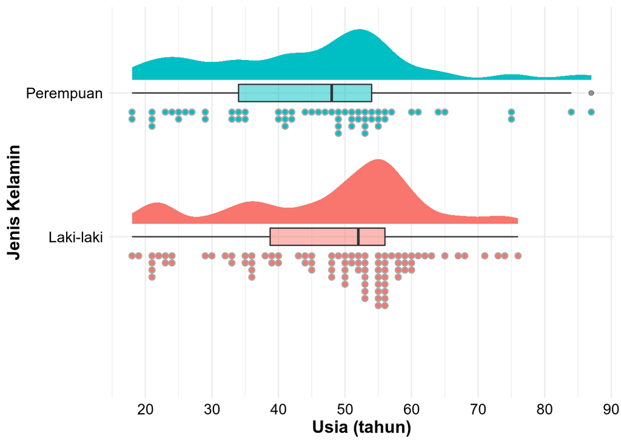

```r
age_dist <- ggplot(data = data, aes(x= Jenis.Kelamin, y=Umur, fill=Jenis.Kelamin)) +
  ggdist::stat_halfeye(adjust=0.5, width=0.5, .width=0, justification=-0.2, point_colour=NA, show.legend = F) +
  geom_boxplot(width=0.12, alpha=0.5, show.legend = F) +
  ggdist::stat_dots(side="left", justification=1.12, binwidth=1, show.legend = F) +
  theme_minimal() +
  labs(
    title = NULL,
    y = "Usia (tahun)",
    x = "Jenis Kelamin",
    fill="Jenis Kelamin"
  ) +
  theme(axis.title.x = element_text(family="arial", face="bold", colour="black", size=14)) +
  theme(axis.title.y = element_text(family="arial", face="bold", colour="black", size=14)) +
  theme(axis.text.x = element_text(family="arial", face="plain", colour="black", size=12)) +
  theme(axis.text.y = element_text(family="arial", face="plain", colour="black", size=12)) +
  scale_y_continuous(breaks=c(seq(from=0, to=90, by=10))) +
  scale_x_discrete(labels=c("Laki-laki", "Perempuan")) +
  coord_flip()

print(age_dist)
```

```r
ggsave("distribusi usia.jpg", bg="white")
```

### Gejala

```r
### Fix Missing Data
gejala_tam_coloumn <- c(9:22)
data[,gejala_tam_coloumn] <- lapply(data[,gejala_tam_coloumn], as.character)
func_missing_data <-function(data) {
    ifelse(grepl("ya", data), "Ada", "Tidak")
}
data[,gejala_tam_coloumn] <- lapply(data[,gejala_tam_coloumn], func_missing_data)


### Recode factor

data[,gejala_tam_coloumn] <- lapply(data[,gejala_tam_coloumn], factor, levels=c("Ada", "Tidak"))

gejala <- data %>%
  select(9:22) %>%
  tbl_summary()

gejala
```

| **Characteristic** | **N = 153**<sup>1</sup> |
| --- | --- |
| gej. tam (batuk) |  |
| Ada | 127 (83%) |
| Tidak | 26 (17%) |
| gej. tam (pilek) |  |
| Ada | 30 (20%) |
| Tidak | 123 (80%) |
| gej. tam (demam) |  |
| Ada | 31 (20%) |
| Tidak | 122 (80%) |
| gej. tam (nyeri tenggorokan) |  |
| Ada | 19 (12%) |
| Tidak | 134 (88%) |
| gej. tam (nyeri dada) |  |
| Ada | 1 (0.7%) |
| Tidak | 152 (99%) |
| gej. tam (sesak) |  |
| Ada | 29 (19%) |
| Tidak | 124 (81%) |
| gej. tam (lemas) |  |
| Ada | 51 (33%) |
| Tidak | 102 (67%) |
| gej. tam (mual) |  |
| Ada | 47 (31%) |
| Tidak | 106 (69%) |
| gej. tam (pusing) |  |
| Ada | 3 (2.0%) |
| Tidak | 150 (98%) |
| gej. tam (muntah) |  |
| Ada | 13 (8.5%) |
| Tidak | 140 (92%) |
| gej. tam (diare) |  |
| Ada | 11 (7.2%) |
| Tidak | 142 (93%) |
| gej. tam (myalgia) |  |
| Ada | 42 (27%) |
| Tidak | 111 (73%) |
| gej. tam (penurunan penciuman) |  |
| Ada | 31 (20%) |
| Tidak | 122 (80%) |
| gej. tam (penurunan pengecap) |  |
| Ada | 18 (12%) |
| Tidak | 135 (88%) |

<sup>*1*</sup> n (%)

```r
gejala_by_severity <- data %>%
  select(9:22,45) %>%
  tbl_summary(by=Derajat_new, missing = "no", percent = "row") %>%
  add_p(test=list(all_continuous() ~ "t.test", all_categorical() ~ "fisher.test")) %>%
  add_n() %>%
  add_overall()

gejala_by_severity
```

| **Characteristic** | **N** | **Overall**, N = 153<sup>1</sup> | **berat**, N = 11<sup>1</sup> | **kritis**, N = 24<sup>1</sup> | **sedang**, N = 118<sup>1</sup> | **p-value**<sup>2</sup> |
| --- | --- | --- | --- | --- | --- | --- |
| gej. tam (batuk) | 153 |  |  |  |  | 0.004 |
| Ada |  | 127 (100%) | 10 (7.9%) | 14 (11%) | 103 (81%) |  |
| Tidak |  | 26 (100%) | 1 (3.8%) | 10 (38%) | 15 (58%) |  |
| gej. tam (pilek) | 153 |  |  |  |  | 0.011 |
| Ada |  | 30 (100%) | 2 (6.7%) | 0 (0%) | 28 (93%) |  |
| Tidak |  | 123 (100%) | 9 (7.3%) | 24 (20%) | 90 (73%) |  |
| gej. tam (demam) | 153 |  |  |  |  | <0.001 |
| Ada |  | 31 (100%) | 2 (6.5%) | 13 (42%) | 16 (52%) |  |
| Tidak |  | 122 (100%) | 9 (7.4%) | 11 (9.0%) | 102 (84%) |  |
| gej. tam (nyeri tenggorokan) | 153 |  |  |  |  | 0.2 |
| Ada |  | 19 (100%) | 0 (0%) | 1 (5.3%) | 18 (95%) |  |
| Tidak |  | 134 (100%) | 11 (8.2%) | 23 (17%) | 100 (75%) |  |
| gej. tam (nyeri dada) | 153 |  |  |  |  | 0.072 |
| Ada |  | 1 (100%) | 1 (100%) | 0 (0%) | 0 (0%) |  |
| Tidak |  | 152 (100%) | 10 (6.6%) | 24 (16%) | 118 (78%) |  |
| gej. tam (sesak) | 153 |  |  |  |  | 0.030 |
| Ada |  | 29 (100%) | 5 (17%) | 6 (21%) | 18 (62%) |  |
| Tidak |  | 124 (100%) | 6 (4.8%) | 18 (15%) | 100 (81%) |  |
| gej. tam (lemas) | 153 |  |  |  |  | 0.5 |
| Ada |  | 51 (100%) | 5 (9.8%) | 9 (18%) | 37 (73%) |  |
| Tidak |  | 102 (100%) | 6 (5.9%) | 15 (15%) | 81 (79%) |  |
| gej. tam (mual) | 153 |  |  |  |  | 0.083 |
| Ada |  | 47 (100%) | 6 (13%) | 4 (8.5%) | 37 (79%) |  |
| Tidak |  | 106 (100%) | 5 (4.7%) | 20 (19%) | 81 (76%) |  |
| gej. tam (pusing) | 153 |  |  |  |  | 0.3 |
| Ada |  | 3 (100%) | 1 (33%) | 0 (0%) | 2 (67%) |  |
| Tidak |  | 150 (100%) | 10 (6.7%) | 24 (16%) | 116 (77%) |  |
| gej. tam (muntah) | 153 |  |  |  |  | 0.4 |
| Ada |  | 13 (100%) | 2 (15%) | 2 (15%) | 9 (69%) |  |
| Tidak |  | 140 (100%) | 9 (6.4%) | 22 (16%) | 109 (78%) |  |
| gej. tam (diare) | 153 |  |  |  |  | 0.12 |
| Ada |  | 11 (100%) | 2 (18%) | 0 (0%) | 9 (82%) |  |
| Tidak |  | 142 (100%) | 9 (6.3%) | 24 (17%) | 109 (77%) |  |
| gej. tam (myalgia) | 153 |  |  |  |  | 0.7 |
| Ada |  | 42 (100%) | 4 (9.5%) | 6 (14%) | 32 (76%) |  |
| Tidak |  | 111 (100%) | 7 (6.3%) | 18 (16%) | 86 (77%) |  |
| gej. tam (penurunan penciuman) | 153 |  |  |  |  | 0.004 |
| Ada |  | 31 (100%) | 1 (3.2%) | 0 (0%) | 30 (97%) |  |
| Tidak |  | 122 (100%) | 10 (8.2%) | 24 (20%) | 88 (72%) |  |
| gej. tam (penurunan pengecap) | 153 |  |  |  |  | 0.11 |
| Ada |  | 18 (100%) | 1 (5.6%) | 0 (0%) | 17 (94%) |  |
| Tidak |  | 135 (100%) | 10 (7.4%) | 24 (18%) | 101 (75%) |  |

<sup>*1*</sup> n (%) <sup>*2*</sup> Fisher's exact test

### Komorbid

```r
### Recode Gejala Overall
data$peny.komorbid <- ifelse(is.na(data$Komorbid), "tidak", data$Komorbid)
data$peny.komorbid <- ifelse(grepl("tidak", data$peny.komorbid), "tidak", "ada")
data$peny.komorbid <- as.factor(data$peny.komorbid)

### recode levels
komorbid_coloumn <- c(24:31)
data[,komorbid_coloumn] <- lapply(data[,komorbid_coloumn], factor, levels=c("ya", "tidak"))

komorbid <- data %>%
  select(24:31,peny.komorbid) %>%
  tbl_summary()

komorbid
```

| **Characteristic** | **N = 153**<sup>1</sup> |
| --- | --- |
| Komorbid_HT |  |
| ya | 33 (22%) |
| tidak | 120 (78%) |
| Komorbid_DM |  |
| ya | 27 (18%) |
| tidak | 126 (82%) |
| Komorbid jantung |  |
| ya | 7 (4.6%) |
| tidak | 146 (95%) |
| komorbid asma |  |
| ya | 3 (2.0%) |
| tidak | 150 (98%) |
| komorbid CKD |  |
| ya | 9 (5.9%) |
| tidak | 144 (94%) |
| komorbid Batu ginjal-saluran kencing |  |
| ya | 2 (1.3%) |
| tidak | 151 (99%) |
| komorbid skizo |  |
| ya | 2 (1.3%) |
| tidak | 151 (99%) |
| komorbid lain (hemato-onkologi) RA, obes, stroke |  |
| ya | 6 (3.9%) |
| tidak | 147 (96%) |
| peny.komorbid |  |
| ada | 64 (42%) |
| tidak | 89 (58%) |

<sup>*1*</sup> n (%)

```r
komorbid <- data %>%
  select(24:31,45,peny.komorbid) %>%
  tbl_summary(by=Derajat_new, percent = "row") %>%
  add_p(test=list(all_categorical() ~ "fisher.test")) %>%
  add_n() %>%
  add_overall()

komorbid
```

| **Characteristic** | **N** | **Overall**, N = 153<sup>1</sup> | **berat**, N = 11<sup>1</sup> | **kritis**, N = 24<sup>1</sup> | **sedang**, N = 118<sup>1</sup> | **p-value**<sup>2</sup> |
| --- | --- | --- | --- | --- | --- | --- |
| Komorbid_HT | 153 |  |  |  |  | <0.001 |
| ya |  | 33 (100%) | 5 (15%) | 13 (39%) | 15 (45%) |  |
| tidak |  | 120 (100%) | 6 (5.0%) | 11 (9.2%) | 103 (86%) |  |
| Komorbid_DM | 153 |  |  |  |  | <0.001 |
| ya |  | 27 (100%) | 5 (19%) | 9 (33%) | 13 (48%) |  |
| tidak |  | 126 (100%) | 6 (4.8%) | 15 (12%) | 105 (83%) |  |
| Komorbid jantung | 153 |  |  |  |  | 0.2 |
| ya |  | 7 (100%) | 1 (14%) | 2 (29%) | 4 (57%) |  |
| tidak |  | 146 (100%) | 10 (6.8%) | 22 (15%) | 114 (78%) |  |
| komorbid asma | 153 |  |  |  |  | >0.9 |
| ya |  | 3 (100%) | 0 (0%) | 0 (0%) | 3 (100%) |  |
| tidak |  | 150 (100%) | 11 (7.3%) | 24 (16%) | 115 (77%) |  |
| komorbid CKD | 153 |  |  |  |  | <0.001 |
| ya |  | 9 (100%) | 1 (11%) | 6 (67%) | 2 (22%) |  |
| tidak |  | 144 (100%) | 10 (6.9%) | 18 (12%) | 116 (81%) |  |
| komorbid Batu ginjal-saluran kencing | 153 |  |  |  |  | 0.2 |
| ya |  | 2 (100%) | 1 (50%) | 0 (0%) | 1 (50%) |  |
| tidak |  | 151 (100%) | 10 (6.6%) | 24 (16%) | 117 (77%) |  |
| komorbid skizo | 153 |  |  |  |  | >0.9 |
| ya |  | 2 (100%) | 0 (0%) | 0 (0%) | 2 (100%) |  |
| tidak |  | 151 (100%) | 11 (7.3%) | 24 (16%) | 116 (77%) |  |
| komorbid lain (hemato-onkologi) RA, obes, stroke | 153 |  |  |  |  | 0.076 |
| ya |  | 6 (100%) | 2 (33%) | 0 (0%) | 4 (67%) |  |
| tidak |  | 147 (100%) | 9 (6.1%) | 24 (16%) | 114 (78%) |  |
| peny.komorbid | 153 |  |  |  |  | <0.001 |
| ada |  | 64 (100%) | 8 (12%) | 24 (38%) | 32 (50%) |  |
| tidak |  | 89 (100%) | 3 (3.4%) | 0 (0%) | 86 (97%) |  |

<sup>*1*</sup> n (%) <sup>*2*</sup> Fisher's exact test

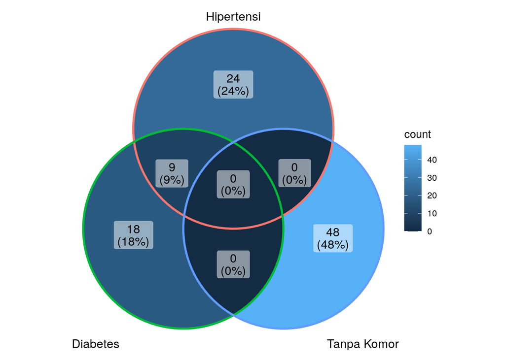

```r
komorbid_list <- list(
 Hipertensi = select(filter(data, Komorbid_HT == "ya"), No),
 Diabetes = select(filter(data, Komorbid_DM == "ya"), No),
 'Tanpa Komorbid' = select(filter(data, Komorbid == "tidak"), No)
 )

komorbid_list <- lapply(komorbid_list, pull)

komorbid_venn <- ggVennDiagram(komorbid_list, show_intersect = F)

komorbid_venn
```

### Treatment & Control

```r
treat <- data %>%
  select(32,33) %>%
  tbl_summary()
treat
```

| **Characteristic** | **N = 153**<sup>1</sup> |
| --- | --- |
| Treatment |  |
| tidak | 1 (0.7%) |
| tidak memiliki komorbid | 89 (58%) |
| ya | 63 (41%) |
| Terkontrol |  |
| tidak | 32 (21%) |
| tidak memiliki komorbid | 89 (58%) |
| ya | 32 (21%) |

<sup>*1*</sup> n (%)

```r
### Perbaiki tidak memiliki komorbid pada treatment anggap missing
data$Treatment <- na_if(data$Treatment, 2)
data$Treatment <- factor(data$Treatment, levels=c("tidak", "ya"))

### perbaiki tidak memiliki komorbid pada terkontrol anggap missing
data$Terkontrol <- na_if(data$Terkontrol, 2)
data$Terkontrol <- factor(data$Terkontrol, levels=c("tidak", "ya"))

treat_by_Severity <- data %>%
  select(peny.komorbid,32,33,45) %>%
  tbl_summary(by=Derajat_new, missing = "no", percent = "row") %>%
  add_p(test=list(all_categorical() ~ "fisher.test")) %>%
  add_n() %>%
  add_overall()

treat_by_Severity
```

| **Characteristic** | **N** | **Overall**, N = 153<sup>1</sup> | **berat**, N = 11<sup>1</sup> | **kritis**, N = 24<sup>1</sup> | **sedang**, N = 118<sup>1</sup> | **p-value**<sup>2</sup> |
| --- | --- | --- | --- | --- | --- | --- |
| peny.komorbid | 153 |  |  |  |  | <0.001 |
| ada |  | 64 (100%) | 8 (12%) | 24 (38%) | 32 (50%) |  |
| tidak |  | 89 (100%) | 3 (3.4%) | 0 (0%) | 86 (97%) |  |
| Treatment | 64 |  |  |  |  | >0.9 |
| tidak |  | 1 (100%) | 0 (0%) | 0 (0%) | 1 (100%) |  |
| ya |  | 63 (100%) | 8 (13%) | 24 (38%) | 31 (49%) |  |
| Terkontrol | 64 |  |  |  |  | <0.001 |
| tidak |  | 32 (100%) | 6 (19%) | 24 (75%) | 2 (6.2%) |  |
| ya |  | 32 (100%) | 2 (6.2%) | 0 (0%) | 30 (94%) |  |

<sup>*1*</sup> n (%) <sup>*2*</sup> Fisher's exact test

### Xray Finding

```r
### recode seragamkan pneumonia
data$Xray <- ifelse(grepl("pneumonia ?", x=as.character(data$Xray)), "pneumonia", as.character(data$Xray))
data$Xray <- as.factor(data$Xray)

xray <- data %>%
  select(Xray) %>%
  tbl_summary()
xray
```

| **Characteristic** | **N = 153**<sup>1</sup> |
| --- | --- |
| Xray |  |
| bronkitis | 9 (5.9%) |
| normal | 110 (72%) |
| pneumonia | 34 (22%) |

<sup>*1*</sup> n (%)

```r
xray_by_severity <- data %>%
  select(Xray, Derajat_new) %>%
  tbl_summary(by=Derajat_new, missing = "no", , percent = "row") %>%
  add_p(test=list(all_categorical() ~ "fisher.test")) %>%
  add_n() %>%
  add_overall()
xray_by_severity
```

| **Characteristic** | **N** | **Overall**, N = 153<sup>1</sup> | **berat**, N = 11<sup>1</sup> | **kritis**, N = 24<sup>1</sup> | **sedang**, N = 118<sup>1</sup> | **p-value**<sup>2</sup> |
| --- | --- | --- | --- | --- | --- | --- |
| Xray | 153 |  |  |  |  | <0.001 |
| bronkitis |  | 9 (100%) | 2 (22%) | 2 (22%) | 5 (56%) |  |
| normal |  | 110 (100%) | 1 (0.9%) | 0 (0%) | 109 (99%) |  |
| pneumonia |  | 34 (100%) | 8 (24%) | 22 (65%) | 4 (12%) |  |

<sup>*1*</sup> n (%) <sup>*2*</sup> Fisher's exact test

### Outcome

```r
### perbaiki rujukan
data$rujukan <- ifelse(grepl("([Ss]anglah|wangaya)", as.character(data$Rujuk)), "Rujuk", as.character(data$Rujuk))
data$rujukan <- as.factor(data$rujukan)

### Missing data meninggal dianggap tidak meninggal
data$meninggal <- ifelse(is.na(data$meninggal), "tidak", "ya")
data$meninggal <- factor(data$meninggal, levels = c("ya", "tidak"))

outcome <- data %>%
  select(41,44:46) %>%
  tbl_summary()

outcome
```

| **Characteristic** | **N = 153**<sup>1</sup> |
| --- | --- |
| Durasi.Rawat.Inap | 12.0 (8.0, 14.0) |
| meninggal |  |
| ya | 3 (2.0%) |
| tidak | 150 (98%) |
| Derajat_new |  |
| berat | 11 (7.2%) |
| kritis | 24 (16%) |
| sedang | 118 (77%) |
| peny.komorbid |  |
| ada | 64 (42%) |
| tidak | 89 (58%) |

<sup>*1*</sup> Median (IQR); n (%)

```r
outcome_by_severity <- data %>%
  select(41,44:46) %>%
  tbl_summary(by=Derajat_new, percent = "row", statistic = list(all_continuous() ~ "{mean} ({sd})")) %>%
  add_p(test=list(all_categorical() ~ "fisher.test", all_continuous() ~ "aov")) %>%
  add_n() %>%
  add_overall()
outcome_by_severity
```

| **Characteristic** | **N** | **Overall**, N = 153<sup>1</sup> | **berat**, N = 11<sup>1</sup> | **kritis**, N = 24<sup>1</sup> | **sedang**, N = 118<sup>1</sup> | **p-value**<sup>2</sup> |
| --- | --- | --- | --- | --- | --- | --- |
| Durasi.Rawat.Inap | 153 | 10.5 (4.2) | 12.8 (2.2) | 3.6 (2.4) | 11.7 (3.1) | <0.001 |
| meninggal | 153 |  |  |  |  | 0.006 |
| ya |  | 3 (100%) | 0 (0%) | 3 (100%) | 0 (0%) |  |
| tidak |  | 150 (100%) | 11 (7.3%) | 21 (14%) | 118 (79%) |  |
| peny.komorbid | 153 |  |  |  |  | <0.001 |
| ada |  | 64 (100%) | 8 (12%) | 24 (38%) | 32 (50%) |  |
| tidak |  | 89 (100%) | 3 (3.4%) | 0 (0%) | 86 (97%) |  |

<sup>*1*</sup> Mean (SD); n (%) <sup>*2*</sup> One-way ANOVA; Fisher's exact test

### Grafik Derajat, usia, DM & HT

```r
data$Derajat_new <- factor(data$Derajat_new, levels = c("sedang", "berat", "kritis"))

anova_int <- summary(aov(data=data, Umur ~ Derajat_new))
anova_int
```

```
##              Df Sum Sq Mean Sq F value   Pr(>F)
## Derajat_new   2   6406    3203   18.65 5.83e-08 ***
## Residuals   150  25760     172
## ---
## Signif. codes:  0 '***' 0.001 '**' 0.01 '*' 0.05 '.' 0.1 ' ' 1
```

```r
anova_p <- anova_int[[1]][[1,"Pr(>F)"]]

anova_text <- paste0("Anova", " ", "p=", anova_int[[1]][[1,"Pr(>F)"]]," ", "(p=",  ifelse(anova_p <= 0.001, print("<0,001"), NA)[1], ")")
```

```
## [1] "<0,001"
```

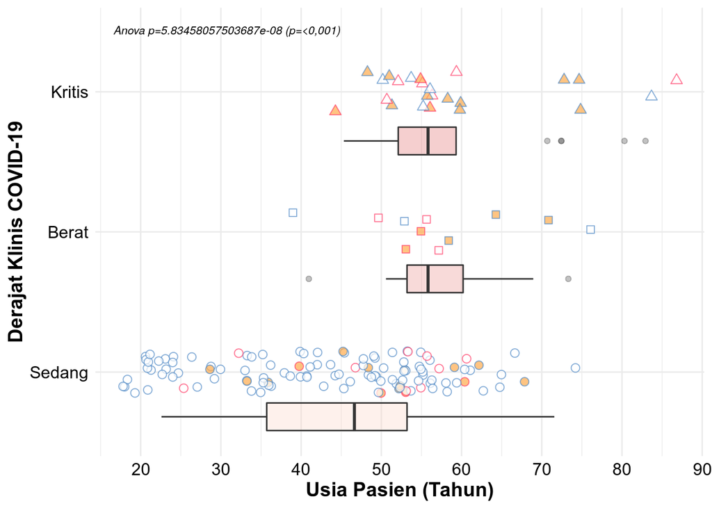

```r
grob_anova <- grobTree(textGrob(anova_text, x=0.03,  y=0.95, hjust=0, gp=gpar(fontsize=8, fontface="italic")))

interaction3 <- ggplot(data = data, aes(x=Umur, y=Derajat_new)) +
  geom_jitter(height=0.15, alpha=0.7, aes(shape=Derajat_new,  colour=Komorbid_DM, fill=Komorbid_HT), show.legend = F, size=2.5) +
  scale_color_manual(values = c("#FF3D68", "#5089C6")) + # outline warna merah/oranye artinya HT
  scale_fill_manual(values = c("#FFAA4C", "#FFFFFF")) + # isi warna merah artinya DM
  scale_shape_manual(values=c(21,22,24)) +
  theme_minimal() +
  xlab("Usia Pasien (Tahun)") +
  ylab("Derajat Klinis COVID-19") +
  theme(axis.title.x = element_text(family="arial", face="bold", colour="black", size=14)) +
  theme(axis.title.y = element_text(family="arial", face="bold", colour="black", size=14)) +
  theme(axis.text.x = element_text(family="arial", face="plain", colour="black", size=12)) +
  theme(axis.text.y = element_text(family="arial", face="plain", colour="black", size=12)) +
  scale_x_continuous(breaks=c(seq(from=0, to=90, by=10))) +
  scale_y_discrete(labels=c("Sedang", "Berat", "Kritis"))


#interaction3

interaction3b <- ggplot(data = data, aes(x=Umur, y=Derajat_new)) +
  geom_boxplot(width=0.2, alpha=0.3, position = "dodge", aes(fill=Derajat_new), show.legend=F) +
  scale_fill_manual(values = c("#FDD2BF", "#E98580", "#DF5E5E")) +
  theme_transparent()
#interaction3b

grob3b <- ggplotGrob(interaction3b)

xmin <- min(data$Umur)
xmax <- max(data$Umur)

interaction3 + annotation_custom(grob = grob3b, xmin = xmin, xmax = xmax, ymin = 0.0 , ymax = 3.3) + annotation_custom(grob_anova)
```

```r
ggsave("interaction.jpg", bg="white")
```

### Grafik Derajat dan lama Rawat Inap

```r
data$Derajat_new <- factor(data$Derajat_new, levels = c("sedang", "berat", "kritis"))

### Anova
anova_los <- summary(aov(data=data, Durasi.Rawat.Inap ~ Derajat_new))
anova_los
```

```
##              Df Sum Sq Mean Sq F value Pr(>F)
## Derajat_new   2   1366   683.1    76.7 <2e-16 ***
## Residuals   150   1336     8.9
## ---
## Signif. codes:  0 '***' 0.001 '**' 0.01 '*' 0.05 '.' 0.1 ' ' 1
```

```r
anova_p_los <-anova_los[[1]][[1,"Pr(>F)"]]

anova_los_text <- paste0("Anova", " ", "p=", anova_los[[1]][[1,"Pr(>F)"]]," ", "(p=",  ifelse(anova_p_los <= 0.001, print("<0,001"), NA)[1], ")")
```

```
## [1] "<0,001"
```

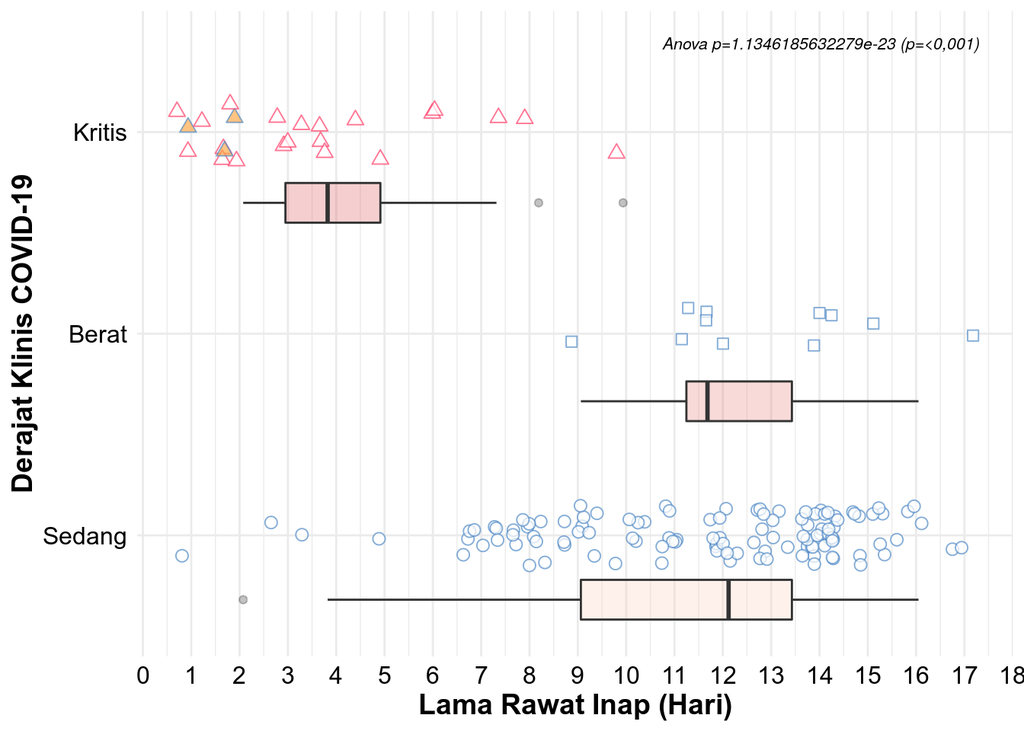

```r
grob_anova_los <- grobTree(textGrob(anova_los_text, x=0.60,  y=0.95, hjust=0, gp=gpar(fontsize=8, fontface="italic")))


los <- ggplot(data=data, aes(x=Durasi.Rawat.Inap, y=Derajat_new)) +
   geom_jitter(height=0.15, alpha=0.7, aes(shape=Derajat_new,  colour=rujukan, fill=meninggal), show.legend = F, size=2.5) +
  scale_color_manual(values = c("#FF3D68", "#5089C6")) + # outline warna merah/oranye artinya rujuk
  scale_fill_manual(values = c("#FFAA4C", "#FFFFFF")) + # isi warna merah artinya meninggal
  scale_shape_manual(values=c(21,22,24)) +
  theme_minimal() +
  xlab("Lama Rawat Inap (Hari)") +
  ylab("Derajat Klinis COVID-19") +
  theme(axis.title.x = element_text(family="arial", face="bold", colour="black", size=14)) +
  theme(axis.title.y = element_text(family="arial", face="bold", colour="black", size=14)) +
  theme(axis.text.x = element_text(family="arial", face="plain", colour="black", size=12)) +
  theme(axis.text.y = element_text(family="arial", face="plain", colour="black", size=12)) +
  scale_x_continuous(breaks=c(seq(from=0, to=18, by=1))) +
  scale_y_discrete(labels=c("Sedang", "Berat", "Kritis"))

#los


los_boxplot <- ggplot(data = data, aes(x=Durasi.Rawat.Inap, y=Derajat_new)) +
  geom_boxplot(width=0.2, alpha=0.3, position = "dodge", aes(fill=Derajat_new), show.legend=F) +
  scale_fill_manual(values = c("#FDD2BF", "#E98580", "#DF5E5E")) +
  theme_transparent()

#los_boxplot

grob_los <- ggplotGrob(los_boxplot)

xmin <- min(data$Durasi.Rawat.Inap)
xmax <- max(data$Durasi.Rawat.Inap)

los + annotation_custom(grob = grob_los, xmin = xmin, xmax = xmax, ymin = 0.0 , ymax = 3.3) + annotation_custom(grob_anova_los)
```

```r
ggsave("los.jpg", bg="white")
```

### Grafik Derajat Klinis dan Saturasi

```r
### Data Saturasi kenapa ada yg persen ada yg ga persen :(
data$Saturasi <- ifelse(data$Saturasi <= 1, data$Saturasi * 100, data$Saturasi)


### Anova
anova_sat <- summary(aov(data=data, Saturasi ~ Derajat_new))
anova_sat
```

```
##              Df Sum Sq Mean Sq F value Pr(>F)
## Derajat_new   2 1850.4   925.2     243 <2e-16 ***
## Residuals   150  571.1     3.8
## ---
## Signif. codes:  0 '***' 0.001 '**' 0.01 '*' 0.05 '.' 0.1 ' ' 1
```

```r
anova_p_sat <-anova_sat[[1]][[1,"Pr(>F)"]]

anova_sat_text <- paste0("Anova", " ", "p=", anova_sat[[1]][[1,"Pr(>F)"]]," ", "(p=",  ifelse(anova_p_sat <= 0.001, print("<0,001"), NA)[1], ")")
```

```
## [1] "<0,001"
```

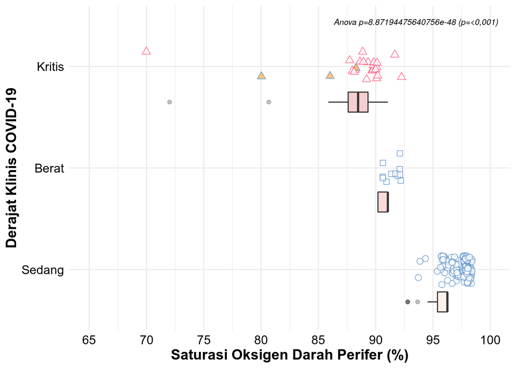

```r
grob_anova_sat <- grobTree(textGrob(anova_sat_text, x=0.60,  y=0.95, hjust=0, gp=gpar(fontsize=8, fontface="italic")))


sat <- ggplot(data=data, aes(x=Saturasi, y=Derajat_new)) +
   geom_jitter(height=0.15, alpha=0.7, aes(shape=Derajat_new,  colour=rujukan, fill=meninggal), show.legend = F, size=2.5) +
  scale_color_manual(values = c("#FF3D68", "#5089C6")) + # outline warna merah/oranye artinya rujuk
  scale_fill_manual(values = c("#FFAA4C", "#FFFFFF")) + # isi warna merah artinya meninggal
  scale_shape_manual(values=c(21,22,24)) +
  theme_minimal() +
  xlab("Saturasi Oksigen Darah Perifer (%)") +
  ylab("Derajat Klinis COVID-19") +
  theme(axis.title.x = element_text(family="arial", face="bold", colour="black", size=14)) +
  theme(axis.title.y = element_text(family="arial", face="bold", colour="black", size=14)) +
  theme(axis.text.x = element_text(family="arial", face="plain", colour="black", size=12)) +
  theme(axis.text.y = element_text(family="arial", face="plain", colour="black", size=12)) +
  #scale_x_continuous(limits = c(60,100)) +
  scale_x_continuous(limits = c(65,100), breaks=c(seq(from=65, to=100, by=5))) +
  scale_y_discrete(labels=c("Sedang", "Berat", "Kritis"))

#sat

sat_boxplot <- ggplot(data = data, aes(x=Saturasi, y=Derajat_new)) +
  geom_boxplot(width=0.2, alpha=0.3, position = "dodge", aes(fill=Derajat_new), show.legend=F) +
  scale_fill_manual(values = c("#FDD2BF", "#E98580", "#DF5E5E")) +
  theme_transparent()

#sat_boxplot

grob_sat <- ggplotGrob(sat_boxplot)

xmin <- min(data$Saturasi)
xmax <- max(data$Saturasi)

sat + annotation_custom(grob = grob_sat, xmin = xmin, xmax = xmax, ymin = 0.0 , ymax = 3.3) + annotation_custom(grob_anova_sat)
```

```r
ggsave("saturasi.jpg", bg="white")
```

## Analisis Sedang vs Berat-Kritis

### Recode Derajat (Sedang & Berat-Kritis)

Analisa jika derajat klinis berat dan kritis digabungkan (menjadi tabel 2x2), sehingga memaksimalkan sampel dan mempermudah interpretasi.

```r
### Recode Derajat menjadi Sedang dan Berat-Kritis
data$derajat_klinis <- ifelse(grepl("(berat|kritis)", as.character(data$Derajat_new)), "berat/kritis", as.character(data$Derajat_new))
data$derajat_klinis <- as.factor(data$derajat_klinis)
summary(data$derajat_klinis)
```

```
## berat/kritis       sedang
##           35          118
```

### Summary Table

```r
data %>%
  select(4:5, 7, 9:22, peny.komorbid, 24:34, 40:41, 44, 46:48) %>%
  tbl_summary(by=derajat_klinis,
              statistic = list(all_continuous() ~ "{mean} ({sd})", all_categorical() ~ "{n} ({p}%)"),
              percent = "row",
              missing = "no") %>%
  add_p(test= list(all_continuous() ~ "t.test", all_categorical() ~ "fisher.test")) %>%
  add_overall() %>%
  add_n() %>%
  modify_caption("<b>Table X.</b> Rangkuman data demografi, klinis dan luaran berdasarkan derajat klinis COVID-19") %>%
  modify_spanning_header(c("stat_1", "stat_2") ~ "**Derajat Klinis COVID-19**") %>%
  modify_header(label ~ "**Variabel**") %>%
  bold_labels()
```

**Table X.** Rangkuman data demografi, klinis dan luaran berdasarkan derajat klinis COVID-19

| **Variabel** | **N** | **Overall**, N = 153<sup>1</sup> | **Derajat Klinis COVID-19** **berat/kritis**, N = 35<sup>1</sup> | **Derajat Klinis COVID-19** **sedang**, N = 118<sup>1</sup> | **p-value**<sup>2</sup> |  |
| --- | --- | --- | --- | --- | --- | --- |
| Jenis.Kelamin | 153 |  |  |  |  | 0.2 |
| laki laki |  | 92 (100%) | 25 (27%) | 67 (73%) |  |  |
| perempuan |  | 61 (100%) | 10 (16%) | 51 (84%) |  |  |
| Umur | 153 | 47 (15) | 59 (11) | 43 (14) | <0.001 |  |
| Gejala.Utama | 153 |  |  |  | <0.001 |  |
| Batuk |  | 11 (100%) | 1 (9.1%) | 10 (91%) |  |  |
| Demam |  | 110 (100%) | 7 (6.4%) | 103 (94%) |  |  |
| lemas |  | 1 (100%) | 1 (100%) | 0 (0%) |  |  |
| Nyeri dada pleuritik |  | 1 (100%) | 0 (0%) | 1 (100%) |  |  |
| penurunan kesadaran |  | 5 (100%) | 5 (100%) | 0 (0%) |  |  |
| sesak |  | 25 (100%) | 21 (84%) | 4 (16%) |  |  |
| gej. tam (batuk) | 153 |  |  |  | 0.019 |  |
| Ada |  | 127 (100%) | 24 (19%) | 103 (81%) |  |  |
| Tidak |  | 26 (100%) | 11 (42%) | 15 (58%) |  |  |
| gej. tam (pilek) | 153 |  |  |  | 0.016 |  |
| Ada |  | 30 (100%) | 2 (6.7%) | 28 (93%) |  |  |
| Tidak |  | 123 (100%) | 33 (27%) | 90 (73%) |  |  |
| gej. tam (demam) | 153 |  |  |  | <0.001 |  |
| Ada |  | 31 (100%) | 15 (48%) | 16 (52%) |  |  |
| Tidak |  | 122 (100%) | 20 (16%) | 102 (84%) |  |  |
| gej. tam (nyeri tenggorokan) | 153 |  |  |  | 0.076 |  |
| Ada |  | 19 (100%) | 1 (5.3%) | 18 (95%) |  |  |
| Tidak |  | 134 (100%) | 34 (25%) | 100 (75%) |  |  |
| gej. tam (nyeri dada) | 153 |  |  |  | 0.2 |  |
| Ada |  | 1 (100%) | 1 (100%) | 0 (0%) |  |  |
| Tidak |  | 152 (100%) | 34 (22%) | 118 (78%) |  |  |
| gej. tam (sesak) | 153 |  |  |  | 0.048 |  |
| Ada |  | 29 (100%) | 11 (38%) | 18 (62%) |  |  |
| Tidak |  | 124 (100%) | 24 (19%) | 100 (81%) |  |  |
| gej. tam (lemas) | 153 |  |  |  | 0.4 |  |

[output cut: 68 more lines]

<sup>*1*</sup> n (%); Mean (SD) <sup>*2*</sup> Fisher's exact test; Welch Two Sample t-test

# Final

## Final Data in Table

**NOTE**: Data Nama dan no.RM tidak ditayangkan

```r
data %>%
  select(c(-1,-2,-3)) %>%
  # knitr::kable("html") %>%
  # kable_styling("striped") %>%
  # scroll_box(width = "100%")
  datatable(options = list(
  pageLength=15, scrollX='400px'), filter = 'top')
```

|  | Jenis.Kelamin | Umur | Tanggal.MRS | Gejala.Utama | Gejala.Tambahan (seluruhnya) | gej. tam (batuk) | gej. tam (pilek) | gej. tam (demam) | gej. tam (nyeri tenggorokan) | gej. tam (nyeri dada) | gej. tam (sesak) | gej. tam (lemas) | gej. tam (mual) | gej. tam (pusing) | gej. tam (muntah) | gej. tam (diare) | gej. tam (myalgia) | gej. tam (penurunan penciuman) | gej. tam (penurunan pengecap) | Komorbid | Komorbid_HT | Komorbid_DM | Komorbid jantung | komorbid asma | komorbid CKD | komorbid Batu ginjal-saluran kencing | komorbid skizo | komorbid lain (hemato-onkologi) RA, obes, stroke | Treatment | … |
| --- | --- | --- | --- | --- | --- | --- | --- | --- | --- | --- | --- | --- | --- | --- | --- | --- | --- | --- | --- | --- | --- | --- | --- | --- | --- | --- | --- | --- | --- | --- |
| 1 | laki laki | 56 | 2021-01-03T00:00:00Z | Demam | batuk | Ada | Tidak | Tidak | Tidak | Tidak | Tidak | Tidak | Tidak | Tidak | Tidak | Tidak | Tidak | Tidak | Tidak |  | tidak | tidak | tidak | tidak | tidak | tidak | tidak | tidak |  | … |
| 2 | laki laki | 44 | 2020-10-31T00:00:00Z | sesak | demam batuk myalgia | Ada | Tidak | Ada | Tidak | Tidak | Tidak | Tidak | Tidak | Tidak | Tidak | Tidak | Ada | Tidak | Tidak |  | tidak | tidak | tidak | tidak | tidak | tidak | tidak | tidak |  | … |
| 3 | laki laki | 71 | 2020-10-02T00:00:00Z | sesak | nyeri dada, mual, myalgia, batuk | Ada | Tidak | Tidak | Tidak | Ada | Tidak | Tidak | Ada | Tidak | Tidak | Tidak | Ada | Tidak | Tidak | CHF, HT | ya | tidak | ya | tidak | tidak | tidak | tidak | tidak | ya | … |
| 4 | laki laki | 53 | 2020-10-03T00:00:00Z | Batuk | Mual/muntah, nyeri ulu hati, lemas, myalgia | Tidak | Tidak | Tidak | Tidak | Tidak | Tidak | Ada | Ada | Tidak | Ada | Tidak | Ada | Tidak | Tidak | CKD, HT, DM | ya | ya | tidak | tidak | ya | tidak | tidak | tidak | ya | … |
| 5 | laki laki | 36 | 2020-10-08T00:00:00Z | Demam | Batuk, myalgia, nyeri tenggorokkan | Ada | Tidak | Tidak | Ada | Tidak | Tidak | Tidak | Tidak | Tidak | Tidak | Tidak | Ada | Tidak | Tidak | tidak | tidak | tidak | tidak | tidak | tidak | tidak | tidak | tidak |  | … |
| 6 | perempuan | 56 | 2020-10-12T00:00:00Z | Demam | batuk, nyeri tenggorokkan | Ada | Tidak | Tidak | Ada | Tidak | Tidak | Tidak | Tidak | Tidak | Tidak | Tidak | Tidak | Tidak | Tidak | tidak | tidak | tidak | tidak | tidak | tidak | tidak | tidak | tidak |  | … |
| 7 | perempuan | 49 | 2020-10-14T00:00:00Z | Batuk | Riw. demam, penurunan penciuman, diare, penurunan pengecapan | Tidak | Tidak | Ada | Tidak | Tidak | Tidak | Tidak | Tidak | Tidak | Tidak | Ada | Tidak | Ada | Ada | tidak | tidak | tidak | tidak | tidak | tidak | tidak | tidak | tidak |  | … |
| 8 | perempuan | 51 | 2020-10-15T00:00:00Z | sesak | demam batuk | Ada | Tidak | Ada | Tidak | Tidak | Tidak | Tidak | Tidak | Tidak | Tidak | Tidak | Tidak | Tidak | Tidak | ht | ya | tidak | tidak | tidak | tidak | tidak | tidak | tidak | ya | … |
| 9 | laki laki | 56 | 2020-10-16T00:00:00Z | Demam | batuk, lemas, myalgia, sesak | Ada | Tidak | Tidak | Tidak | Tidak | Ada | Ada | Tidak | Tidak | Tidak | Tidak | Ada | Tidak | Tidak | tidak | tidak | tidak | tidak | tidak | tidak | tidak | tidak | tidak |  | … |
| 10 | perempuan | 60 | 2020-10-17T00:00:00Z | Demam | Lemas, batuk, sesak | Tidak | Tidak | Tidak | Tidak | Tidak | Ada | Ada | Tidak | Tidak | Tidak | Tidak | Tidak | Tidak | Tidak | DM, HT | ya | ya | tidak | tidak | tidak | tidak | tidak | tidak | ya | … |

[output cut: 143 more lines]

## Bivariat Table Derajat Klinis (Sedang & Berat-Kritis) vs Everything Else

```r
biv_p <- data %>%
  select(4:5, 7, 9:22, peny.komorbid, 24:34, 40:41, 44, 46:48) %>%
  tbl_summary(by=derajat_klinis,
              statistic = list(all_continuous() ~ "{mean} ({sd})", all_categorical() ~ "{n} ({p}%)"),
              percent = "row",
              missing = "no") %>%
  add_p(test= list(all_continuous() ~ "t.test", all_categorical() ~ "fisher.test")) %>%
  add_overall() %>%
  add_n() %>%
  modify_caption("<b>Table X.</b> Rangkuman data demografi, klinis dan luaran berdasarkan derajat klinis COVID-19") %>%
  modify_spanning_header(c("stat_1", "stat_2") ~ "**Derajat Klinis COVID-19**") %>%
  modify_header(label ~ "**Variabel**") %>%
  bold_labels()

biv_p
```

**Table X.** Rangkuman data demografi, klinis dan luaran berdasarkan derajat klinis COVID-19

| **Variabel** | **N** | **Overall**, N = 153<sup>1</sup> | **Derajat Klinis COVID-19** **berat/kritis**, N = 35<sup>1</sup> | **Derajat Klinis COVID-19** **sedang**, N = 118<sup>1</sup> | **p-value**<sup>2</sup> |  |
| --- | --- | --- | --- | --- | --- | --- |
| Jenis.Kelamin | 153 |  |  |  |  | 0.2 |
| laki laki |  | 92 (100%) | 25 (27%) | 67 (73%) |  |  |
| perempuan |  | 61 (100%) | 10 (16%) | 51 (84%) |  |  |
| Umur | 153 | 47 (15) | 59 (11) | 43 (14) | <0.001 |  |
| Gejala.Utama | 153 |  |  |  | <0.001 |  |
| Batuk |  | 11 (100%) | 1 (9.1%) | 10 (91%) |  |  |
| Demam |  | 110 (100%) | 7 (6.4%) | 103 (94%) |  |  |
| lemas |  | 1 (100%) | 1 (100%) | 0 (0%) |  |  |
| Nyeri dada pleuritik |  | 1 (100%) | 0 (0%) | 1 (100%) |  |  |
| penurunan kesadaran |  | 5 (100%) | 5 (100%) | 0 (0%) |  |  |
| sesak |  | 25 (100%) | 21 (84%) | 4 (16%) |  |  |
| gej. tam (batuk) | 153 |  |  |  | 0.019 |  |
| Ada |  | 127 (100%) | 24 (19%) | 103 (81%) |  |  |
| Tidak |  | 26 (100%) | 11 (42%) | 15 (58%) |  |  |
| gej. tam (pilek) | 153 |  |  |  | 0.016 |  |
| Ada |  | 30 (100%) | 2 (6.7%) | 28 (93%) |  |  |
| Tidak |  | 123 (100%) | 33 (27%) | 90 (73%) |  |  |
| gej. tam (demam) | 153 |  |  |  | <0.001 |  |
| Ada |  | 31 (100%) | 15 (48%) | 16 (52%) |  |  |
| Tidak |  | 122 (100%) | 20 (16%) | 102 (84%) |  |  |
| gej. tam (nyeri tenggorokan) | 153 |  |  |  | 0.076 |  |
| Ada |  | 19 (100%) | 1 (5.3%) | 18 (95%) |  |  |
| Tidak |  | 134 (100%) | 34 (25%) | 100 (75%) |  |  |
| gej. tam (nyeri dada) | 153 |  |  |  | 0.2 |  |
| Ada |  | 1 (100%) | 1 (100%) | 0 (0%) |  |  |
| Tidak |  | 152 (100%) | 34 (22%) | 118 (78%) |  |  |
| gej. tam (sesak) | 153 |  |  |  | 0.048 |  |
| Ada |  | 29 (100%) | 11 (38%) | 18 (62%) |  |  |
| Tidak |  | 124 (100%) | 24 (19%) | 100 (81%) |  |  |
| gej. tam (lemas) | 153 |  |  |  | 0.4 |  |

[output cut: 68 more lines]

<sup>*1*</sup> n (%); Mean (SD) <sup>*2*</sup> Fisher's exact test; Welch Two Sample t-test

```r
sect_properties <- prop_section(
  page_size = page_size(orient = "landscape",
    width = 8.3, height = 11.7),
  type = "continuous",
  page_margins = page_mar()
)
biv_p%>%
  as_flex_table() %>%
  save_as_docx(biv_p, path = "biv.p.table.docx", pr_section = sect_properties)
```

```r
drive_upload(media = "biv.p.table.docx", path = as_id("https://drive.google.com/drive/u/2/folders/1LcqP38WQYIIxNeWaoDAb85MZjCTYgnXh"))
```

[output not shown]

[output not shown]

[output not shown]

[output not shown]

```
## Local file:
##   * biv.p.table.docx
## uploaded into Drive file:
##   * biv.p.table.docx: 1CnVVGvFTAro7WbHalWZ3LbcWOpeDxEjU
## with MIME type:
##   * application/vnd.openxmlformats-officedocument.wordprocessingml.document
```

## Waktu & Frequency

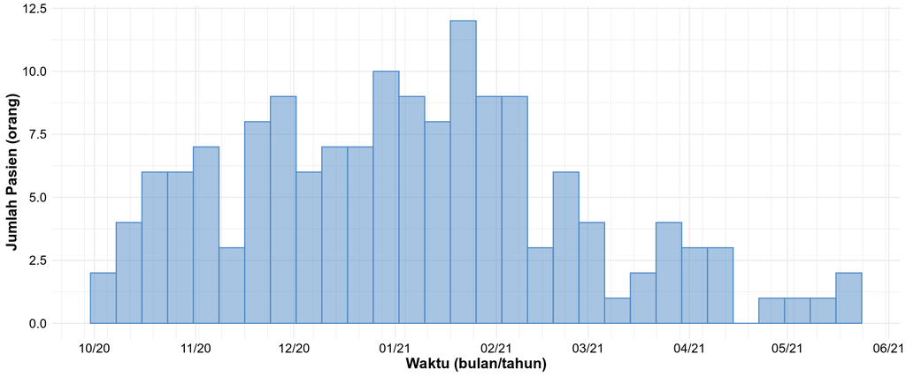

```r
data_waktu <-data %>%
  select(Tanggal.MRS, derajat_klinis) %>%
  mutate(jumlah=1)

data_waktu <- data_waktu %>%
  mutate(month=format(Tanggal.MRS, "%m %Y"))
data_waktu$month <- format(data_waktu$month, format= "%m %Y")

date <- ggplot(data=data, aes(x=as.Date(Tanggal.MRS))) +
  geom_histogram(fill="#5089C6", alpha=0.5, color="#5089C6") +
  scale_x_date(date_labels = "%m/%y",
               date_breaks = "1 month",
               date_minor_breaks = "1 week") +
  theme_minimal() +
  labs(
    title = NULL,
    y = "Jumlah Pasien (orang)",
    x = "Waktu (bulan/tahun)") +
  theme(axis.title.x = element_text(family="arial", face="bold", colour="black", size=14)) +
  theme(axis.title.y = element_text(family="arial", face="bold", colour="black", size=14)) +
  theme(axis.text.x = element_text(family="arial", face="plain", colour="black", size=12)) +
  theme(axis.text.y = element_text(family="arial", face="plain", colour="black", size=12))
date
```

## Usia & Gender

```r
age_dist_gender <- ggplot(data = data, aes(x= Jenis.Kelamin, y=Umur, fill=Jenis.Kelamin)) +
  ggdist::stat_halfeye(adjust=0.5, width=0.5, .width=0, justification=-0.2, point_colour=NA, show.legend = F) +
  geom_boxplot(width=0.12, alpha=0.5, show.legend = F) +
  ggdist::stat_dots(side="left", justification=1.12, binwidth=1, show.legend = F) +
  theme_minimal() +
  labs(
    title = NULL,
    y = "Usia (tahun)",
    x = "Jenis Kelamin",
    fill="Jenis Kelamin"
  ) +
  theme(axis.title.x = element_text(family="arial", face="bold", colour="black", size=14)) +
  theme(axis.title.y = element_text(family="arial", face="bold", colour="black", size=14)) +
  theme(axis.text.x = element_text(family="arial", face="plain", colour="black", size=12)) +
  theme(axis.text.y = element_text(family="arial", face="plain", colour="black", size=12)) +
  scale_y_continuous(breaks=c(seq(from=0, to=90, by=10))) +
  scale_x_discrete(labels=c("Laki-laki", "Perempuan")) +
  coord_flip()

#print(age_dist_gender)
```

```r
age_dist <- ggplot(data = data, aes(y=Umur)) +
  ggdist::stat_halfeye(adjust=0.5, width=0.5, .width=0, justification=-0.2, point_colour=NA, show.legend = F, fill="#5089C6", alpha=0.5) +
  geom_boxplot(width=0.12, alpha=0.5, show.legend = F, color="#DF5E5E", fill="#E98580", alpha=0.5) +
  ggdist::stat_dots(side="left", justification=1.12, binwidth=1, show.legend = F, fill="#5089C6", alpha=0.5) +
  theme_minimal() +
  labs(
    title = NULL,
    y = "Usia (tahun)",
    x = NULL) +
  theme(axis.title.x = element_text(family="arial", face="bold", colour="black", size=14)) +
  theme(axis.title.y = element_text(family="arial", face="bold", colour="black", size=14)) +
  theme(axis.text.x = element_text(family="arial", face="plain", colour="black", size=12)) +
  theme(axis.text.y = element_text(family="arial", face="plain", colour="black", size=12)) +
  scale_y_continuous(breaks=c(seq(from=0, to=90, by=10))) +
  scale_x_discrete(element_blank()) +
  coord_flip()

#print(age_dist)
```

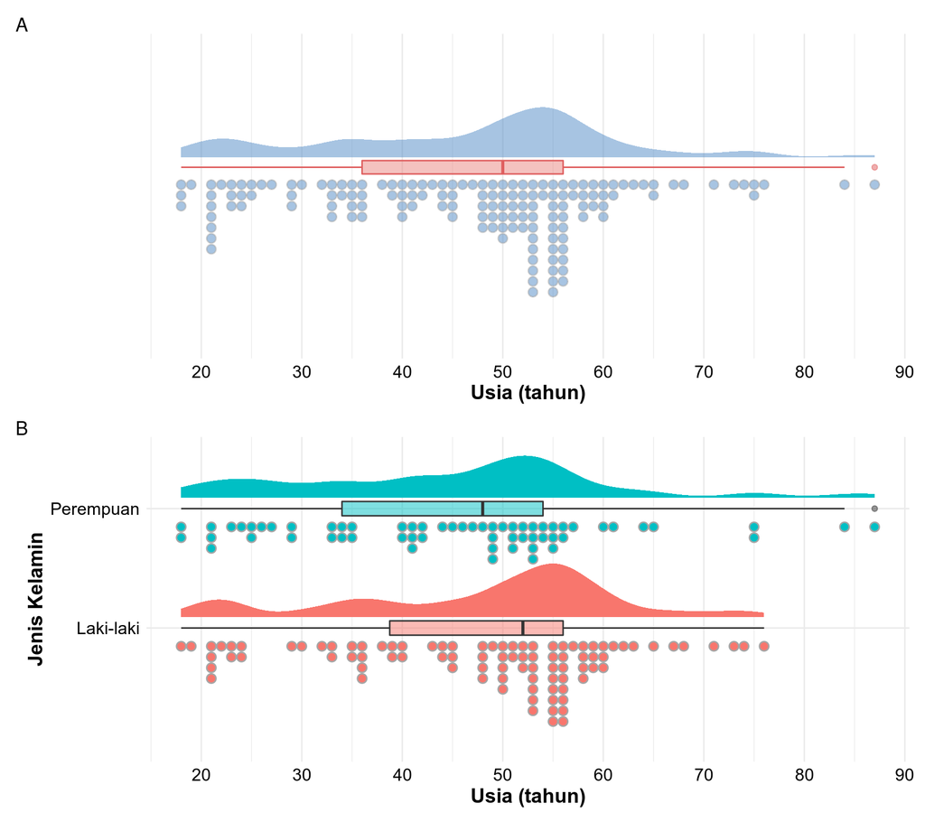

```r
age_dist/age_dist_gender + plot_annotation(tag_levels = "A")
```

```r
ggsave("distribusi usia.jpg", bg="white")
```

## Derajat Klinis ~ Usia

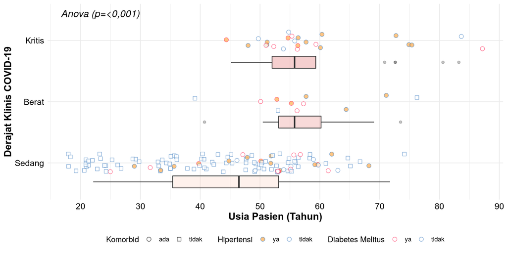

```r
interaction3 <- ggplot(data = data, aes(x=Umur, y=Derajat_new)) +
  geom_jitter(height=0.15, alpha=0.7, aes(shape=peny.komorbid,  colour=Komorbid_DM, fill=Komorbid_HT), show.legend = T, size=2.5) +
  scale_color_manual(values = c("#FF3D68", "#5089C6")) + # outline warna merah/oranye artinya DM
  scale_fill_manual(values = c("#FFAA4C", "#FFFFFF")) + # isi warna merah artinya HT
  scale_shape_manual(values=c(21,22,24)) +
  theme_minimal() +
  xlab("Usia Pasien (Tahun)") +
  ylab("Derajat Klinis COVID-19") +
  theme(axis.title.x = element_text(family="arial", face="bold", colour="black", size=14)) +
  theme(axis.title.y = element_text(family="arial", face="bold", colour="black", size=14)) +
  theme(axis.text.x = element_text(family="arial", face="plain", colour="black", size=12)) +
  theme(axis.text.y = element_text(family="arial", face="plain", colour="black", size=12)) +
  scale_x_continuous(breaks=c(seq(from=0, to=90, by=10))) +
  scale_y_discrete(labels=c("Sedang", "Berat", "Kritis")) +
  theme(legend.position = "bottom") +
  guides(color = guide_legend(override.aes = list(shape=21, color = c("#FF3D68", "#5089C6")))) +
  guides(fill = guide_legend(override.aes = list(shape=21, fill = c("#FFAA4C", "#FFFFFF"), color = "#5089C6"))) +
  labs(colour = "Diabetes Melitus", fill = "Hipertensi", shape = "Komorbid")


#interaction3

interaction3b <- ggplot(data = data, aes(x=Umur, y=Derajat_new)) +
  geom_boxplot(width=0.2, alpha=0.3, position = "dodge", aes(fill=Derajat_new), show.legend=F) +
  scale_fill_manual(values = c("#FDD2BF", "#E98580", "#DF5E5E")) +
  theme_transparent()
#interaction3b

grob3b <- ggplotGrob(interaction3b)

xmin <- min(data$Umur)
xmax <- max(data$Umur)

interaction3 + annotation_custom(grob = grob3b, xmin = xmin, xmax = xmax, ymin = 0.0 , ymax = 3.3) + annotation_custom(grob_anova)
```

```r
ggsave("interaction.jpg", bg="white")
```

## Derajat Klinis ~ Saturasi O2

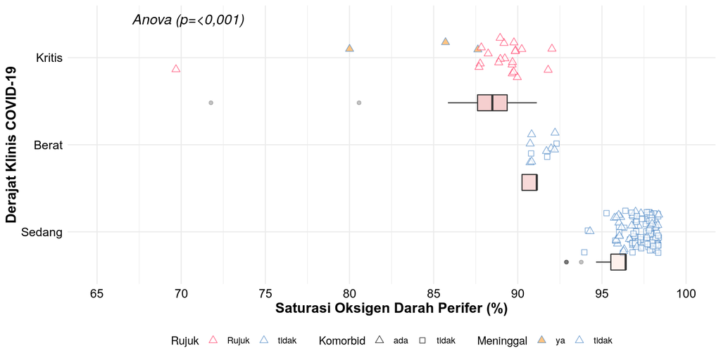

```r
sat <- ggplot(data=data, aes(x=Saturasi, y=Derajat_new)) +
   geom_jitter(height=0.25, alpha=0.7, aes(shape=peny.komorbid,  colour=rujukan, fill=meninggal), show.legend = T, size=2.5) +
  scale_color_manual(values = c("#FF3D68", "#5089C6")) + # outline warna merah/oranye artinya rujuk
  scale_fill_manual(values = c("#FFAA4C", "#FFFFFF")) + # isi warna merah artinya meninggal
  scale_shape_manual(values=c(24,22)) +
  theme_minimal() +
  xlab("Saturasi Oksigen Darah Perifer (%)") +
  ylab("Derajat Klinis COVID-19") +
  theme(axis.title.x = element_text(family="arial", face="bold", colour="black", size=14)) +
  theme(axis.title.y = element_text(family="arial", face="bold", colour="black", size=14)) +
  theme(axis.text.x = element_text(family="arial", face="plain", colour="black", size=12)) +
  theme(axis.text.y = element_text(family="arial", face="plain", colour="black", size=12)) +
  scale_x_continuous(limits = c(65,100), breaks=c(seq(from=65, to=100, by=5))) +
  scale_y_discrete(labels=c("Sedang", "Berat", "Kritis")) +
  theme(legend.position = "bottom") +
  guides(color = guide_legend(override.aes = list(shape=24, color = c("#FF3D68", "#5089C6")))) +
  guides(fill = guide_legend(override.aes = list(shape=24, fill = c("#FFAA4C", "#FFFFFF"), color = "#5089C6"))) +
  guides(shape = guide_legend(override.aes = list(shape=c(24,22)))) +
  labs(colour = "Rujuk", fill = "Meninggal", shape = "Komorbid")

#sat

sat_boxplot <- ggplot(data = data, aes(x=Saturasi, y=Derajat_new)) +
  geom_boxplot(width=0.2, alpha=0.3, position = "dodge", aes(fill=Derajat_new), show.legend=F) +
  scale_fill_manual(values = c("#FDD2BF", "#E98580", "#DF5E5E")) +
  theme_transparent()

#sat_boxplot

grob_sat <- ggplotGrob(sat_boxplot)

xmin <- min(data$Saturasi)
xmax <- max(data$Saturasi)

sat + annotation_custom(grob = grob_sat, xmin = xmin, xmax = xmax, ymin = 0.00 , ymax = 3.1) + annotation_custom(grob_anova_sat)
```

```r
ggsave("saturasi.jpg", bg="white")
```

## Durasi Rawat Inap ~ Derajat Klinis

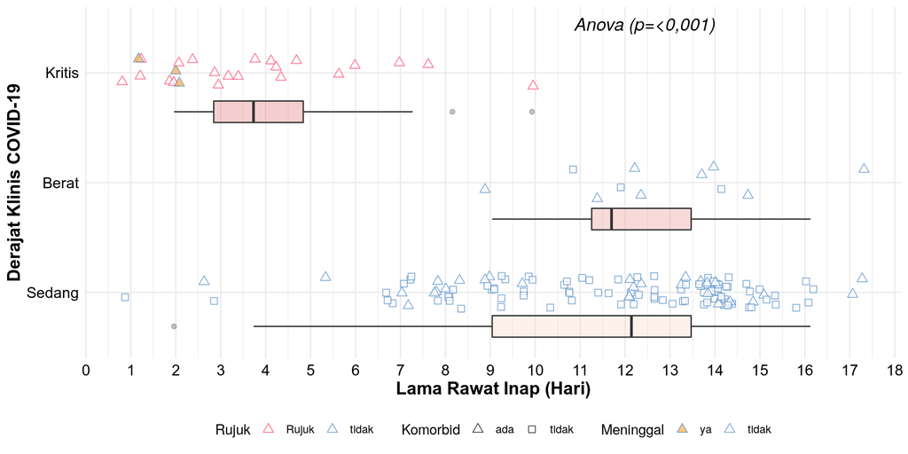

```r
los <- ggplot(data=data, aes(x=Durasi.Rawat.Inap, y=Derajat_new)) +
   geom_jitter(height=0.15, alpha=0.7, aes(shape=peny.komorbid,  colour=rujukan, fill=meninggal), show.legend = T, size=2.5) +
  scale_color_manual(values = c("#FF3D68", "#5089C6")) + # outline warna merah/oranye artinya rujuk
  scale_fill_manual(values = c("#FFAA4C", "#FFFFFF")) + # isi warna merah artinya meninggal
  scale_shape_manual(values=c(24,22)) +
  theme_minimal() +
  xlab("Lama Rawat Inap (Hari)") +
  ylab("Derajat Klinis COVID-19") +
  theme(axis.title.x = element_text(family="arial", face="bold", colour="black", size=14)) +
  theme(axis.title.y = element_text(family="arial", face="bold", colour="black", size=14)) +
  theme(axis.text.x = element_text(family="arial", face="plain", colour="black", size=12)) +
  theme(axis.text.y = element_text(family="arial", face="plain", colour="black", size=12)) +
  scale_x_continuous(breaks=c(seq(from=0, to=18, by=1))) +
  scale_y_discrete(labels=c("Sedang", "Berat", "Kritis")) +
  theme(legend.position = "bottom") +
  guides(color = guide_legend(override.aes = list(shape=24, color = c("#FF3D68", "#5089C6")))) +
  guides(fill = guide_legend(override.aes = list(shape=24, fill = c("#FFAA4C", "#FFFFFF"), color = "#5089C6"))) +
  guides(shape = guide_legend(override.aes = list(shape=c(24,22)))) +
  labs(colour = "Rujuk", fill = "Meninggal", shape = "Komorbid")

#los


los_boxplot <- ggplot(data = data, aes(x=Durasi.Rawat.Inap, y=Derajat_new)) +
  geom_boxplot(width=0.2, alpha=0.3, position = "dodge", aes(fill=Derajat_new), show.legend=F) +
  scale_fill_manual(values = c("#FDD2BF", "#E98580", "#DF5E5E")) +
  theme_transparent()

#los_boxplot

grob_los <- ggplotGrob(los_boxplot)

xmin <- min(data$Durasi.Rawat.Inap)
xmax <- max(data$Durasi.Rawat.Inap)

los + annotation_custom(grob = grob_los, xmin = xmin, xmax = xmax, ymin = 0.0 , ymax = 3.3) + annotation_custom(grob_anova_los)
```

```r
ggsave("los.jpg", bg="white")
```

```r
med.los_binary <- data %>%
  select(Durasi.Rawat.Inap, derajat_klinis) %>%
  tbl_summary(by=derajat_klinis,
              statistic = list(all_continuous() ~ "{median} ({p25}, {p75})", all_categorical() ~ "{n} ({p}%)"),
              percent = "row",
              missing = "no") %>%
  add_p(test= list(all_continuous() ~ "wilcox.test", all_categorical() ~ "fisher.test")) %>%
  add_overall() %>%
  add_n() %>%
  modify_caption("<b>Table X.</b> Median Rawat Inap berdasarkan derajat klinis COVID-19") %>%
  modify_spanning_header(c("stat_1", "stat_2") ~ "**Derajat Klinis COVID-19**") %>%
  modify_header(label ~ "**Variabel**") %>%
  bold_labels()
med.los_binary
```

**Table X.** Median Rawat Inap berdasarkan derajat klinis COVID-19

| **Variabel** | **N** | **Overall**, N = 153<sup>1</sup> | **Derajat Klinis COVID-19** **berat/kritis**, N = 35<sup>1</sup> | **Derajat Klinis COVID-19** **sedang**, N = 118<sup>1</sup> | **p-value**<sup>2</sup> |  |
| --- | --- | --- | --- | --- | --- | --- |
| Durasi.Rawat.Inap | 153 | 12.0 (8.0, 14.0) | 4.0 (2.0, 11.0) | 12.5 (9.0, 14.0) |  | <0.001 |

<sup>*1*</sup> Median (IQR) <sup>*2*</sup> Wilcoxon rank sum test

```r
med.los_binary <- data %>%
  select(Durasi.Rawat.Inap, Derajat_new) %>%
  tbl_summary(by=Derajat_new,
              statistic = list(all_continuous() ~ "{median} ({p25}, {p75})", all_categorical() ~ "{n} ({p}%)"),
              percent = "row",
              missing = "no") %>%
  add_p(test= list(all_continuous() ~ "aov", all_categorical() ~ "fisher.test")) %>%
  add_overall() %>%
  add_n() %>%
  modify_caption("<b>Table X.</b> Median Rawat Inap berdasarkan derajat klinis COVID-19") %>%
  modify_spanning_header(c("stat_1", "stat_2") ~ "**Derajat Klinis COVID-19**") %>%
  modify_header(label ~ "**Variabel**") %>%
  bold_labels()
med.los_binary
```

**Table X.** Median Rawat Inap berdasarkan derajat klinis COVID-19

| **Variabel** | **N** | **Overall**, N = 153<sup>1</sup> | **Derajat Klinis COVID-19** **sedang**, N = 118<sup>1</sup> | **Derajat Klinis COVID-19** **berat**, N = 11<sup>1</sup> | **kritis**, N = 24<sup>1</sup> | **p-value**<sup>2</sup> |  |  |
| --- | --- | --- | --- | --- | --- | --- | --- | --- |
| Durasi.Rawat.Inap | 153 | 12.0 (8.0, 14.0) | 12.5 (9.0, 14.0) | 12.0 (11.5, 14.0) |  |  | 3.0 (2.0, 4.2) | <0.001 |

<sup>*1*</sup> Median (IQR) <sup>*2*</sup> One-way ANOVA

## Bivariate & Multivariate

### Finding Cutoff Numeric Variable

#### Usia

```r
cut_umur <- cutpointr(data=data,
          x=Umur,
          class=derajat_klinis,
          method = maximize_metric,
          metric = sum_sens_spec)
```

```
## Assuming the positive class is berat/kritis
```

```
## Assuming the positive class has higher x values
```

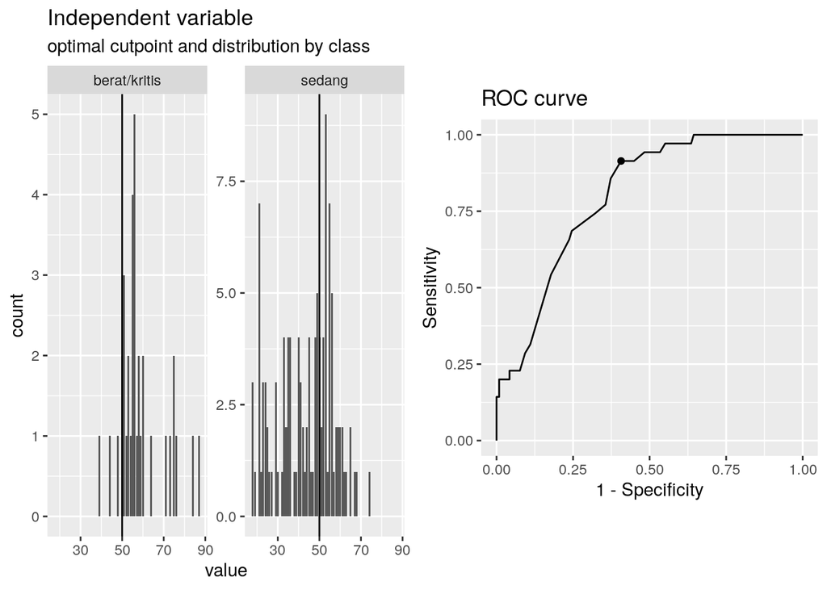

```r
s_cut_umur <- summary(cut_umur)
p_cut_umur <- plot(cut_umur)
```

```r
s_cut_umur
```

```
## Method: maximize_metric
## Predictor: Umur
## Outcome: derajat_klinis
## Direction: >=
##
##     AUC   n n_pos n_neg
##  0.8005 153    35   118
##
##  optimal_cutpoint sum_sens_spec    acc sensitivity specificity tp fn fp tn
##                50        1.5075 0.6667      0.9143      0.5932 32  3 48 70
##
## Predictor summary:
##          Data Min.   5% 1st Qu. Median     Mean 3rd Qu.   95% Max.       SD NAs
##       Overall   18 21.0    36.0   50.0 46.79739      56 69.20   87 14.54727   0
##  berat/kritis   39 46.8    52.5   56.0 58.65714      60 78.40   87 10.75651   0
##        sedang   18 21.0    33.0   45.5 43.27966      53 62.15   74 13.66566   0
```

```r
p_cut_umur
```

Optimal Cut Point untuk **Umur** adalah **50** tahun.

```r
data$usia_cut <- ifelse(data$Umur < 50, "Kurang dari 50", "Lebih dari/sama 50")
data$usia_cut <- factor(data$usia_cut, levels = c("Lebih dari/sama 50", "Kurang dari 50"))
```

#### Saturasi Oksigen

```r
cut_sat <- cutpointr(data=data,
          x=Saturasi,
          class=derajat_klinis,
          method = maximize_metric,
          metric = sum_sens_spec)
```

```
## Assuming the positive class is sedang
```

```
## Assuming the positive class has higher x values
```

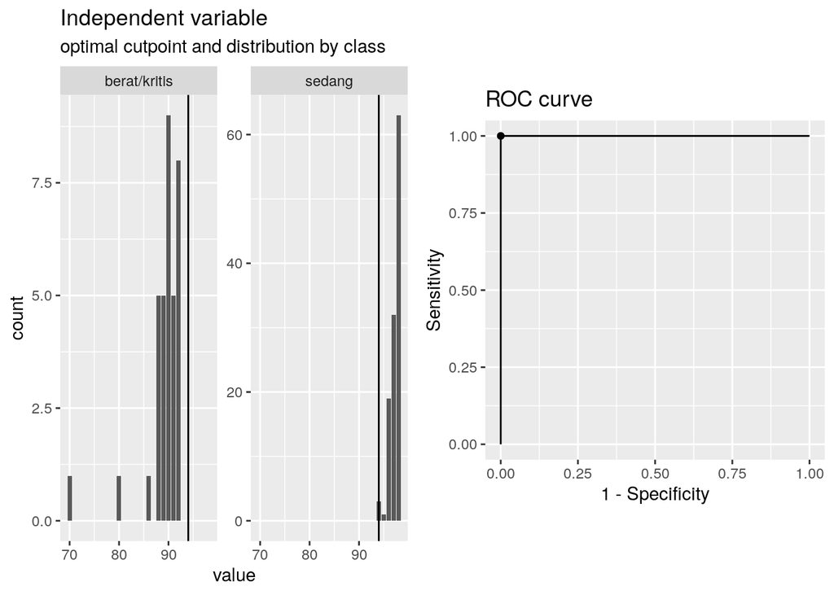

```r
s_cut_sat <- summary(cut_sat)
p_cut_sat <- plot(cut_sat)
```

```r
s_cut_sat
```

```
## Method: maximize_metric
## Predictor: Saturasi
## Outcome: derajat_klinis
## Direction: >=
##
##  AUC   n n_pos n_neg
##    1 153   118    35
##
##  optimal_cutpoint sum_sens_spec acc sensitivity specificity  tp fn fp tn
##                94             2   1           1           1 118  0  0 35
##
## Predictor summary:
##          Data Min.   5% 1st Qu. Median     Mean 3rd Qu. 95% Max.        SD NAs
##       Overall   70 88.6      95     97 95.43137      98  98   98 3.9913800   0
##  berat/kritis   70 84.2      89     90 89.20000      91  92   92 4.0424221   0
##        sedang   94 96.0      97     98 97.27966      98  98   98 0.9417713   0
```

```r
p_cut_sat
```

Optimal Cut Point untuk **Saturasi** adalah **94**%.

```r
data$saturasi_cut <- ifelse(data$Saturasi < 94, "Kurang dari 94%", "Lebih dari/sama 94%")
data$saturasi_cut <- factor(data$saturasi_cut, levels = c("Kurang dari 94%", "Lebih dari/sama 94%"))
```

### Bivariate odd_ratio

#### Recode Variabel Menjadi Binary

```r
### Xray
data$xray_binary <- as.character(data$Xray)
data$xray_binary <- ifelse(data$xray_binary == "normal", "Normal", "Abnormal")
data$xray_binary <- factor(data$xray_binary, levels = c("Abnormal", "Normal"))

### Gejala utama sesak
data$gej.utama.sesak <- as.character(data$Gejala.Utama)
data$gej.utama.sesak <- ifelse(data$gej.utama.sesak == "sesak", "Sesak Napas", "Bukan Sesak")
data$gej.utama.sesak <- factor(data$gej.utama.sesak, levels = c("Sesak Napas", "Bukan Sesak"))
```

#### Bivariate Analysis

```r
# data %>%
#   select(Jenis.Kelamin, usia_cut, gej.utama.sesak, saturasi_cut, xray_binary, peny.komorbid, derajat_klinis) %>%
#   tbl_summary(by=derajat_klinis,
#               statistic = list(all_continuous() ~ "{mean} ({sd})", all_categorical() ~ "{n} ({p}%)"),
#               percent = "row",
#               missing = "no") %>%
#   add_p(test= list(all_continuous() ~ "t.test", all_categorical() ~ "fisher.test")) %>%
#   add_overall() %>%
#   add_n() %>%
#   modify_caption("<b>Table Y.</b> Data Jenis Kelamin, Sesak, Saturasi, Xray, Komorbid berdasarkan derajat klinis COVID-19") %>%
#   modify_spanning_header(c("stat_1", "stat_2") ~ "**Derajat Klinis COVID-19**") %>%
#   modify_header(label ~ "**Variabel**") %>%
#   bold_labels()
```

```r
data_biv <- data %>%
  select(4, peny.komorbid, 24:25, `komorbid CKD`, 48:49,51:52)

odd_r <- function(data, variable, by, ...) {
  #variable = deparse(substitute(variable))
  #by = deparse(substitute(by))
  o <-oddsratio(x=data[[variable]], y=as.factor(data[[by]]))
  odd <- style_sigfig(o$measure[2])
  ci <- style_sigfig(o$measure[c(4,6)]) %>% paste(collapse = ", ")
  str_glue("{odd} ({ci})")
}

biv_table <- data_biv %>%
  #select(1,2,6,5) %>%
  tbl_summary(by=derajat_klinis,
              statistic = list(all_categorical() ~ "{n} ({p}%)"),
              percent = "row",
              missing = "no") %>%
  add_p(test= list(all_categorical() ~ "fisher.test")) %>%
  add_stat(fns = everything() ~ odd_r, fmt_fun = NULL, location = c(everything() ~ "label")) %>%
  modify_header(list(add_stat_1 ~ "**OR (95% CI)**", all_stat_cols() ~ "**{level}**")) %>%
  add_overall() %>%
  add_n() %>%
  modify_caption("<b>Table Y.</b> Rangkuman data demografi, klinis dan luaran berdasarkan derajat klinis COVID-19") %>%
  modify_spanning_header(c("stat_1", "stat_2") ~ "**Derajat Klinis COVID-19**") %>%
  modify_header(label ~ "**Variabel**") %>%
  bold_labels()
```

```
## There was an warning for variable 'komorbid CKD':
##  simpleWarning in chisq.test(xx, correct = correction): Chi-squared approximation may be incorrect
```

```r
biv_table
```

**Table Y.** Rangkuman data demografi, klinis dan luaran berdasarkan derajat klinis COVID-19

| **Variabel** | **N** | **Overall**, N = 153<sup>1</sup> | **Derajat Klinis COVID-19** **berat/kritis**<sup>1</sup> | **Derajat Klinis COVID-19** **sedang**<sup>1</sup> | **p-value**<sup>2</sup> | **OR (95% CI)** |  |  |
| --- | --- | --- | --- | --- | --- | --- | --- | --- |
| Jenis.Kelamin | 153 |  |  |  |  |  | 0.2 | 1.9 (0.84, 4.5) |
| laki laki |  | 92 (100%) | 25 (27%) | 67 (73%) |  |  |  |  |
| perempuan |  | 61 (100%) | 10 (16%) | 51 (84%) |  |  |  |  |
| peny.komorbid | 153 |  |  |  | <0.001 | 27 (8.8, 122) |  |  |
| ada |  | 64 (100%) | 32 (50%) | 32 (50%) |  |  |  |  |
| tidak |  | 89 (100%) | 3 (3.4%) | 86 (97%) |  |  |  |  |
| Komorbid_HT | 153 |  |  |  | <0.001 | 7.1 (3.0, 17) |  |  |
| ya |  | 33 (100%) | 18 (55%) | 15 (45%) |  |  |  |  |
| tidak |  | 120 (100%) | 17 (14%) | 103 (86%) |  |  |  |  |
| Komorbid_DM | 153 |  |  |  | <0.001 | 5.3 (2.2, 13) |  |  |
| ya |  | 27 (100%) | 14 (52%) | 13 (48%) |  |  |  |  |
| tidak |  | 126 (100%) | 21 (17%) | 105 (83%) |  |  |  |  |
| komorbid CKD | 153 |  |  |  | <0.001 | 13 (3.0, 104) |  |  |
| ya |  | 9 (100%) | 7 (78%) | 2 (22%) |  |  |  |  |
| tidak |  | 144 (100%) | 28 (19%) | 116 (81%) |  |  |  |  |
| usia_cut | 153 |  |  |  | <0.001 | 15 (4.9, 66) |  |  |
| Lebih dari/sama 50 |  | 80 (100%) | 32 (40%) | 48 (60%) |  |  |  |  |
| Kurang dari 50 |  | 73 (100%) | 3 (4.1%) | 70 (96%) |  |  |  |  |
| xray_binary | 153 |  |  |  | <0.001 | 334 (62, 8,341) |  |  |
| Abnormal |  | 43 (100%) | 34 (79%) | 9 (21%) |  |  |  |  |
| Normal |  | 110 (100%) | 1 (0.9%) | 109 (99%) |  |  |  |  |
| gej.utama.sesak | 153 |  |  |  | <0.001 | 40 (13, 157) |  |  |
| Sesak Napas |  | 25 (100%) | 21 (84%) | 4 (16%) |  |  |  |  |
| Bukan Sesak |  | 128 (100%) | 14 (11%) | 114 (89%) |  |  |  |  |

<sup>*1*</sup> n (%) <sup>*2*</sup> Fisher's exact test

```r
sect_properties <- prop_section(
  page_size = page_size(orient = "landscape",
    width = 8.3, height = 11.7),
  type = "continuous",
  page_margins = page_mar()
)
biv_table%>%
  as_flex_table() %>%
  save_as_docx(biv_table, path = "biv.odd.table.docx", pr_section = sect_properties)
```

```r
drive_upload(media = "biv.odd.table.docx", path = as_id("https://drive.google.com/drive/u/2/folders/1LcqP38WQYIIxNeWaoDAb85MZjCTYgnXh"))
```

```
## Local file:
##   * biv.odd.table.docx
## uploaded into Drive file:
##   * biv.odd.table.docx: 1EjWSbb0Chn5Qy_kB5qIx96jge_GCC3kG
## with MIME type:
##   * application/vnd.openxmlformats-officedocument.wordprocessingml.document
```

Jenis kelamin tidak berhubungan dengan derajat klinis. Saturasi oksigen memberikan separasi 100 dari derajat klinis. Antara perfect predictor atau karena data yang kurang bervariasi. Jenis kelamin dan Saturasi oksigen tidak dimasukan ke Model Regresi Logistik.

### Binary Logistic Regression

```r
### Refactor
data$usia_cut <- factor(data$usia_cut, levels = c("Kurang dari 50", "Lebih dari/sama 50"))
data$xray_binary <- factor(data$xray_binary, levels = c("Normal", "Abnormal"))
data$gej.utama.sesak <- factor(data$gej.utama.sesak, levels = c("Bukan Sesak", "Sesak Napas"))
data$peny.komorbid <- factor(data$peny.komorbid, levels = c("tidak", "ada"))
data$`komorbid CKD` <- factor(data$`komorbid CKD`, levels = c("tidak", "ya"))
data$Komorbid_DM <- factor(data$Komorbid_DM, levels = c("tidak", "ya"))
data$derajat_klinis <- factor(data$derajat_klinis, levels = c("sedang", "berat/kritis"))



logres <- glm(derajat_klinis ~ usia_cut + gej.utama.sesak + xray_binary + Komorbid_HT + Komorbid_DM + `komorbid CKD`,
              data = data,
              family = binomial)
summary(logres)
```

```
##
## Call:
## glm(formula = derajat_klinis ~ usia_cut + gej.utama.sesak + xray_binary +
##     Komorbid_HT + Komorbid_DM + `komorbid CKD`, family = binomial,
##     data = data)
##
## Deviance Residuals:
##      Min        1Q    Median        3Q       Max
## -2.37064  -0.06607  -0.04944  -0.04944   2.90745
##
## Coefficients:
##                            Estimate Std. Error z value Pr(>|z|)
## (Intercept)                 -4.9247     1.4904  -3.304 0.000952 ***
## usia_cutLebih dari/sama 50   0.5806     1.2500   0.464 0.642330
## gej.utama.sesakSesak Napas   1.4357     0.9302   1.543 0.122747
## xray_binaryAbnormal          5.5241     1.3630   4.053 5.06e-05 ***
## Komorbid_HTtidak            -1.7819     0.9801  -1.818 0.069068 .
## Komorbid_DMya                1.9141     1.0666   1.795 0.072729 .
## `komorbid CKD`ya             2.7286     1.8967   1.439 0.150258
## ---
## Signif. codes:  0 '***' 0.001 '**' 0.01 '*' 0.05 '.' 0.1 ' ' 1
##
## (Dispersion parameter for binomial family taken to be 1)
##
##     Null deviance: 164.558  on 152  degrees of freedom
## Residual deviance:  39.387  on 146  degrees of freedom
## AIC: 53.387
##
## Number of Fisher Scoring iterations: 8
```

```r
multi <- tbl_regression(logres,
               exponentiate = TRUE) %>%
  add_global_p() %>%
  bold_p(t = 0.05) %>%
  bold_labels() %>%
  italicize_levels() %>%
  modify_caption("<b>Table Z.</b> <i>Adjusted Odd Ratio</i> dari beberapa prediktor derajat klinis COVID-19") %>%
  modify_header(label ~ "**Variabel**")
```

```
## add_global_p: Global p-values for variable(s) `add_global_p(include =
## c("usia_cut", "gej.utama.sesak", "xray_binary", "Komorbid_HT", "Komorbid_DM",
## "komorbid CKD"))` were calculated with
##   `car::Anova(x$model_obj, type = "III")`
```

```r
multi
```

**Table Z.** *Adjusted Odd Ratio* dari beberapa prediktor derajat klinis COVID-19

| **Variabel** | **OR**<sup>1</sup> | **95% CI**<sup>1</sup> | **p-value** |
| --- | --- | --- | --- |
| usia_cut |  |  | 0.6 |
| Kurang dari 50 | — | — |  |
| Lebih dari/sama 50 | 1.79 | 0.15, 22.4 |  |
| gej.utama.sesak |  |  | 0.12 |
| Bukan Sesak | — | — |  |
| Sesak Napas | 4.20 | 0.70, 29.9 |  |
| xray_binary |  |  | <0.001 |
| Normal | — | — |  |
| Abnormal | 251 | 28.7, 8,048 |  |
| Komorbid_HT |  |  | 0.053 |
| ya | — | — |  |
| tidak | 0.17 | 0.02, 1.03 |  |
| Komorbid_DM |  |  | 0.052 |
| tidak | — | — |  |
| ya | 6.78 | 0.98, 72.5 |  |
| komorbid CKD |  |  | 0.085 |
| tidak | — | — |  |
| ya | 15.3 | 0.74, 1,238 |  |

<sup>*1*</sup> OR = Odds Ratio, CI = Confidence Interval

```r
sect_properties <- prop_section(
  page_size = page_size(orient = "landscape",
    width = 8.3, height = 11.7),
  type = "continuous",
  page_margins = page_mar()
)
multi%>%
  as_flex_table() %>%
  save_as_docx(multi, path = "multivariate.docx", pr_section = sect_properties)
```

```r
drive_upload(media = "multivariate.docx", path = as_id("https://drive.google.com/drive/u/2/folders/1LcqP38WQYIIxNeWaoDAb85MZjCTYgnXh"))
```

```
## Local file:
##   * multivariate.docx
## uploaded into Drive file:
##   * multivariate.docx: 1B8NVyjEA6aKYCp-b4vIL-O7Oy4DWXy8T
## with MIME type:
##   * application/vnd.openxmlformats-officedocument.wordprocessingml.document
```

#### Revised

```r
### Refactor
data$Komorbid_HT <- factor(data$Komorbid_HT, levels = c("tidak", "ya"))
data$Komorbid_DM <- factor(data$Komorbid_DM, levels = c("tidak", "ya"))
#data$derajat_klinis <- factor(data$derajat_klinis, levels = c("sedang", "berat/kritis"))



logres2 <- glm(derajat_klinis ~ Komorbid_HT + Komorbid_DM,
              data = data,
              family = binomial)
summary(logres2)
```

```
##
## Call:
## glm(formula = derajat_klinis ~ Komorbid_HT + Komorbid_DM, family = binomial,
##     data = data)
##
## Deviance Residuals:
##     Min       1Q   Median       3Q      Max
## -1.8228  -0.4612  -0.4612  -0.4612   2.1418
##
## Coefficients:
##               Estimate Std. Error z value Pr(>|z|)
## (Intercept)    -2.1873     0.3140  -6.965 3.28e-12 ***
## Komorbid_HTya   1.9713     0.4634   4.254 2.10e-05 ***
## Komorbid_DMya   1.6668     0.4990   3.340 0.000838 ***
## ---
## Signif. codes:  0 '***' 0.001 '**' 0.01 '*' 0.05 '.' 0.1 ' ' 1
##
## (Dispersion parameter for binomial family taken to be 1)
##
##     Null deviance: 164.56  on 152  degrees of freedom
## Residual deviance: 132.23  on 150  degrees of freedom
## AIC: 138.23
##
## Number of Fisher Scoring iterations: 4
```

```r
multi2 <- tbl_regression(logres2,
               exponentiate = TRUE) %>%
  add_global_p() %>%
  bold_p(t = 0.05) %>%
  bold_labels() %>%
  italicize_levels() %>%
  modify_caption("<b>Table Z.</b> <i>Adjusted Odd Ratio</i> dari beberapa prediktor derajat klinis COVID-19") %>%
  modify_header(label ~ "**Variabel**")
```

```
## add_global_p: Global p-values for variable(s) `add_global_p(include =
## c("Komorbid_HT", "Komorbid_DM"))` were calculated with
##   `car::Anova(x$model_obj, type = "III")`
```

```r
multi2
```

**Table Z.** *Adjusted Odd Ratio* dari beberapa prediktor derajat klinis COVID-19

| **Variabel** | **OR**<sup>1</sup> | **95% CI**<sup>1</sup> | **p-value** |
| --- | --- | --- | --- |
| Komorbid_HT |  |  | <0.001 |
| tidak | — | — |  |
| ya | 7.18 | 2.94, 18.3 |  |
| Komorbid_DM |  |  | <0.001 |
| tidak | — | — |  |
| ya | 5.30 | 2.00, 14.4 |  |

<sup>*1*</sup> OR = Odds Ratio, CI = Confidence Interval

# Citation

**Detail for Reproducible Research** **Software yang digunakan untuk analisa**

## Citation

- R Core Team (2021). R: A language and environment for statistical computing. R Foundation for Statistical Computing, Vienna, Austria. URL https://www.R-project.org/.
- JJ Allaire and Yihui Xie and Jonathan McPherson and Javier Luraschi and Kevin Ushey and Aron Atkins and Hadley Wickham and Joe Cheng and Winston Chang and Richard Iannone (2021). rmarkdown: Dynamic Documents for R. R package version 2.7. URL https://rmarkdown.rstudio.com.
- Jennifer Bryan (2021). googlesheets4: Access Google Sheets using the Sheets API V4. R package version 0.3.0. https://CRAN.R-project.org/package=googlesheets4
- Lucy D’Agostino McGowan and Jennifer Bryan (2020). googledrive: An Interface to Google Drive. R package version 1.0.1. https://CRAN.R-project.org/package=googledrive
- Wickham et al., (2019). Welcome to the tidyverse. Journal of Open Source Software, 4(43), 1686, https://doi.org/10.21105/joss.01686
- H. Wickham. ggplot2: Elegant Graphics for Data Analysis. Springer-Verlag New York, 2016.
- Richard Iannone, Joe Cheng and Barret Schloerke (2021). gt: Easily Create Presentation-Ready Display Tables. R package version 0.3.0. https://CRAN.R-project.org/package=gt
- Daniel D. Sjoberg, Michael Curry, Margie Hannum, Joseph Larmarange, Karissa Whiting and Emily C. Zabor (2021). gtsummary: Presentation-Ready Data Summary and Analytic Result Tables. R package version 1.4.2. https://CRAN.R-project.org/package=gtsummary
- Chun-Hui Gao (2021). ggVennDiagram: A ‘ggplot2’ Implement of Venn Diagram. R package version 1.1.4. https://CRAN.R-project.org/package=ggVennDiagram
- Kay M (2021). *ggdist: Visualizations of Distributions and Uncertainty*. doi: 10.5281/zenodo.3879620 (URL: https://doi.org/10.5281/zenodo.3879620), R package version 3.0.0, https://mjskay.github.io/ggdist/.
- Thomas Lin Pedersen (2020). patchwork: The Composer of Plots. R package version 1.1.1. https://CRAN.R-project.org/package=patchwork
- Yihui Xie, Joe Cheng and Xianying Tan (2021). DT: A Wrapper of the JavaScript Library ‘DataTables’. R package version 0.18. https://CRAN.R-project.org/package=DT
- Thiele C, Hirschfeld G (2021). “cutpointr: Improved Estimation and Validation of Optimal Cutpoints in R.” *Journal of Statistical Software*, *98*(11), 1-27. doi: 10.18637/jss.v098.i11 (URL:https://doi.org/10.18637/jss.v098.i11).
- Alboukadel Kassambara (2020). ggpubr: ‘ggplot2’ Based Publication Ready Plots. R package version 0.4.0. https://CRAN.R-project.org/package=ggpubr
- Tomas J. Aragon (2020). epitools: Epidemiology Tools. R package version 0.5-10.1. https://CRAN.R-project.org/package=epitools
- David Gohel (2021). officer: Manipulation of Microsoft Word and PowerPoint Documents. R package version 0.3.19. https://CRAN.R-project.org/package=officer